# Mid-Term Project

#### Overview

- Use Medicare CCLF Claims from Syntegra dataset to answer key business questions
- Extra credit for building up on the questions below (additional questions + answers)
- One Jupyter notebook solution with clear Python code and all cell outputs available
- At least two data quality checks

## Step 0. Prepare raw input datasets

Here we will 1) load original datasets, 2) remove unused columns, 3) de-duplicate rows, and 4) join datasets, not necessarily in this order

Assumptions:

- Claim ID (cur_clm_uniq_id) represents one claim, which may or may not have more than one code (code could be HCPCS/CPT, diagnosis, procedure...)
- There is a one-to-many relationship between patient IDs (bene_mbi_id) and claim IDs (cur_clm_uniq_id), i.e. each claim is unique to one patient, but one patient can have more than one claim

### 0.1 Import required packages

```python
import numpy as np
import pandas as pd
```

```python
# Turn off the automatic setting that redacts the columns/rows from the dataframe output
pd.set_option('display.max_columns', None)
#pd.set_option('display.max_rows', 200)
```

### 0.2 Load & select columns to be used from raw (original) datasets

### 0.2.1 Load & select columns from Claims Header dataset

```python
# Load Claims Header dataset
parta_claims_header_raw_df = pd.read_csv("parta_claims_header.csv")
parta_claims_header_raw_df.sort_values(by=['cur_clm_uniq_id'])
```

|  | cur_clm_uniq_id | prvdr_oscar_num | bene_mbi_id | bene_hic_num | clm_type_cd | clm_from_dt | clm_thru_dt | clm_bill_fac_type_cd | clm_bill_clsfctn_cd | prncpl_dgns_cd | admtg_dgns_cd | clm_mdcr_npmt_rsn_cd | clm_pmt_amt | clm_nch_prmry_pyr_cd | prvdr_fac_fips_st_cd | bene_ptnt_stus_cd | dgns_drg_cd | clm_op_srvc_type_cd | fac_prvdr_npi_num | oprtg_prvdr_npi_num | atndg_prvdr_npi_num | othr_prvdr_npi_num | clm_adjsmt_type_cd | clm_efctv_dt | clm_idr_ld_dt | bene_eqtbl_bic_hicn_num | clm_admsn_type_cd | clm_admsn_src_cd | clm_bill_freq_cd | … |
| --- | --- | --- | --- | --- | --- | --- | --- | --- | --- | --- | --- | --- | --- | --- | --- | --- | --- | --- | --- | --- | --- | --- | --- | --- | --- | --- | --- | --- | --- | --- |
| 510 | 100190 | 111821 | 1228 | NaN | 40 | 2018-06-10 | 2018-06-10 | 7 | 7 | M1611 | NaN | NaN | 127.79 | NaN | 11 | 1 | NaN | F | 1780608992 | NaN | 1.972732e+09 | NaN | NaN | NaN | NaN | NaN | NaN | NaN | 1 | … |
| 521 | 100402 | 100226 | 1261 | NaN | 60 | 2017-05-27 | 2017-06-02 | 1 | 1 | K5733 | K5733 | NaN | 10602.46 | NaN | 10 | 6 | 330.0 | NaN | 1689611501 | NaN | 1.285688e+09 | NaN | NaN | NaN | NaN | NaN | 1.0 | 1 | 1 | … |
| 525 | 100464 | 360051 | 12978 | NaN | 40 | 2017-06-26 | 2017-06-26 | 1 | 3 | R079 | NaN | NaN | 199.45 | NaN | 36 | 1 | NaN | C | 1073688354 | NaN | 1.982693e+09 | NaN | NaN | NaN | NaN | NaN | NaN | NaN | 1 | … |
| 536 | 100698 | 140276 | 11789 | NaN | 40 | 2017-07-28 | 2017-07-28 | 1 | 3 | M545 | NaN | NaN | 85.25 | NaN | 14 | 1 | NaN | C | 1376521575 | NaN | 1.912991e+09 | NaN | NaN | NaN | NaN | NaN | NaN | NaN | 1 | … |
| 540 | 100750 | 230216 | 12138 | NaN | 40 | 2018-01-13 | 2018-01-13 | 1 | 3 | Z0289 | NaN | N | 0.00 | NaN | 23 | 9 | NaN | C | 1982685384 | NaN | 1.063442e+09 | NaN | NaN | NaN | NaN | NaN | NaN | NaN | 0 | … |
| ... | ... | ... | ... | ... | ... | ... | ... | ... | ... | ... | ... | ... | ... | ... | ... | ... | ... | ... | ... | ... | ... | ... | ... | ... | ... | ... | ... | ... | ... | … |
| 230 | 1698691 | 390145 | 10007 | NaN | 40 | 2016-12-11 | 2016-12-11 | 1 | 3 | Z01818 | NaN | NaN | 43.01 | NaN | 39 | 1 | NaN | C | 1689691214 | NaN | 1.679505e+09 | NaN | NaN | NaN | NaN | NaN | NaN | NaN | 1 | … |
| 4365 | 1698722 | 200021 | 10985 | NaN | 40 | 2018-06-16 | 2018-06-16 | 1 | 3 | E782 | NaN | NaN | 179.09 | NaN | 20 | 1 | NaN | C | 1932164795 | NaN | 1.548289e+09 | NaN | NaN | NaN | NaN | NaN | NaN | NaN | 1 | … |
| 4366 | 1698935 | 210022 | 1297 | NaN | 40 | 2018-04-06 | 2018-04-06 | 1 | 3 | I110 | NaN | NaN | 400.81 | NaN | 21 | 9 | NaN | C | 1205896446 | NaN | 1.922016e+09 | NaN | NaN | NaN | NaN | NaN | NaN | NaN | 1 | … |
| 4367 | 1699005 | 100057 | 12194 | NaN | 40 | 2016-04-27 | 2016-04-27 | 1 | 3 | I348 | NaN | NaN | 265.19 | NaN | 10 | 1 | NaN | C | 1821019571 | NaN | 1.437130e+09 | NaN | NaN | NaN | NaN | NaN | NaN | NaN | 1 | … |
| 4368 | 1699102 | 330191 | 11842 | NaN | 60 | 2017-01-30 | 2017-02-03 | 1 | 1 | I441 | R42 | NaN | 6476.96 | NaN | 33 | 3 | 287.0 | NaN | 1871606764 | NaN | 1.679594e+09 | NaN | NaN | NaN | NaN | NaN | 1.0 | 1 | 1 | … |

8626 rows × 37 columns

#### Data Quality Check #1: If true, the original dataset was unique on claim ID

```python
parta_claims_header_raw_df_count = parta_claims_header_raw_df.shape[0]
parta_claims_header_raw_uniq_clm_id_df = parta_claims_header_raw_df['cur_clm_uniq_id'].drop_duplicates()

parta_claims_header_raw_df_count == parta_claims_header_raw_uniq_clm_id_df.shape[0]
```

```
True
```

```python
# Select only the desired columns (renaming if needed) and remove duplicates if any
parta_claims_header_df = parta_claims_header_raw_df[[
    'cur_clm_uniq_id', 'bene_mbi_id', 'atndg_prvdr_npi_num',
    'clm_from_dt', 'prncpl_dgns_cd', 'clm_pmt_amt'
]].drop_duplicates().rename(
    columns={
        'cur_clm_uniq_id': 'claim_id',
        'bene_mbi_id': 'patient_id',
        'clm_from_dt': 'claim_date',
        'atndg_prvdr_npi_num': 'npi_id'
    }
)
parta_claims_header_df
```

|  | claim_id | patient_id | npi_id | claim_date | prncpl_dgns_cd | clm_pmt_amt |
| --- | --- | --- | --- | --- | --- | --- |
| 0 | 1001595 | 10226 | 1.366492e+09 | 2018-02-28 | M25551 | 259.01 |
| 1 | 1004555 | 10133 | 1.942275e+09 | 2018-11-02 | Z9861 | 29.56 |
| 2 | 1011605 | 10163 | 1.578546e+09 | 2018-01-02 | C439 | 45.88 |
| 3 | 1011758 | 1003 | 1.952368e+09 | 2018-06-12 | R310 | 9.40 |
| 4 | 101424 | 10052 | 1.336125e+09 | 2016-04-13 | L821 | 34.18 |
| ... | ... | ... | ... | ... | ... | ... |
| 8621 | 999774 | 10367 | NaN | 2017-11-06 | R072 | 374.08 |
| 8622 | 999808 | 10496 | 1.740225e+09 | 2017-07-19 | R079 | 360.89 |
| 8623 | 999878 | 12160 | 1.497784e+09 | 2018-01-18 | R5383 | 90.73 |
| 8624 | 999961 | 12090 | 1.083691e+09 | 2018-03-10 | C73 | 329.44 |
| 8625 | 999976 | 10768 | 1.770564e+09 | 2016-01-18 | E785 | 25.60 |

8626 rows × 6 columns

#### Data Quality Check #2: If true, the filtered dataset did not have any duplicates

```python
parta_claims_header_df_count = parta_claims_header_df.shape[0]

parta_claims_header_raw_df_count == parta_claims_header_df_count
```

```
True
```

#### Data Quality Check #3: If the resulting dataframe is empty, it means all the records have diagnosis code (if it's not empty it should be removed now since we want only the ones with valid codes for analysis)

```python
parta_claims_header_df.loc[~parta_claims_header_df.prncpl_dgns_cd.notnull()]
```

|  | claim_id | patient_id | npi_id | claim_date | prncpl_dgns_cd | clm_pmt_amt |
| --- | --- | --- | --- | --- | --- | --- |

### 0.2.2 Load & select columns from Claims Revenue Center dataset

```python
# Load Claims Revenue Center dataset
# Note this dataset has more than one record for each claim ID (cur_clm_uniq_id)
# Also note there are two sets of date columns,
#  one for claim ID (clm_from/thru_dt) and one for claim line (clm_line_from/thru_dt)
parta_claims_revenue_center_detail_raw_df = pd.read_csv(
    "parta_claims_revenue_center_detail.csv"
)
parta_claims_revenue_center_detail_raw_df.sort_values(by=['cur_clm_uniq_id'])
```

|  | cur_clm_uniq_id | clm_line_num | bene_mbi_id | bene_hic_num | clm_type_cd | clm_line_from_dt | clm_line_thru_dt | clm_line_prod_rev_ctr_cd | clm_line_instnl_rev_ctr_dt | clm_line_hcpcs_cd | bene_eqtbl_bic_hicn_num | prvdr_oscar_num | clm_from_dt | clm_thru_dt | clm_line_srvc_unit_qty | clm_line_cvrd_pd_amt | hcpcs_1_mdfr_cd | hcpcs_2_mdfr_cd | hcpcs_3_mdfr_cd | hcpcs_4_mdfr_cd | hcpcs_5_mdfr_cd | clm_rev_apc_hipps_cd |
| --- | --- | --- | --- | --- | --- | --- | --- | --- | --- | --- | --- | --- | --- | --- | --- | --- | --- | --- | --- | --- | --- | --- |
| 318 | 100073 | 1 | 12620 | NaN | 40 | 2018-12-02 00:00:00 | 2018-12-02 00:00:00 | 403 | 2018-12-02 00:00:00 | 77063 | NaN | NaN | 2018-12-02 00:00:00 | 2018-12-02 00:00:00 | 1 | 24.11 | NaN | NaN | NaN | NaN | NaN | 00000 |
| 383 | 100184 | 1 | 10080 | NaN | 40 | 2018-09-06 00:00:00 | 2018-09-06 00:00:00 | 1 | NaN | NaN | NaN | NaN | 2018-09-06 00:00:00 | 2018-09-06 00:00:00 | 0 | 0.00 | NaN | NaN | NaN | NaN | NaN | 00000 |
| 384 | 100190 | 1 | 1228 | NaN | 40 | 2018-06-10 00:00:00 | 2018-06-10 00:00:00 | 521 | 2018-06-10 00:00:00 | G0467 | NaN | NaN | 2018-06-10 00:00:00 | 2018-06-10 00:00:00 | 1 | 133.74 | NaN | NaN | NaN | NaN | NaN | 00000 |
| 385 | 100190 | 2 | 1228 | NaN | 40 | 2018-06-10 00:00:00 | 2018-06-10 00:00:00 | 521 | 2018-06-10 00:00:00 | 98960 | NaN | NaN | 2018-06-10 00:00:00 | 2018-06-10 00:00:00 | 1 | 0.00 | NaN | NaN | NaN | NaN | NaN | 00000 |
| 386 | 100190 | 3 | 1228 | NaN | 40 | 2018-06-10 00:00:00 | 2018-06-10 00:00:00 | 521 | 2018-06-10 00:00:00 | J1100 | NaN | NaN | 2018-06-10 00:00:00 | 2018-06-10 00:00:00 | 4 | 0.00 | NaN | NaN | NaN | NaN | NaN | 00000 |
| ... | ... | ... | ... | ... | ... | ... | ... | ... | ... | ... | ... | ... | ... | ... | ... | ... | ... | ... | ... | ... | ... | ... |
| 29896 | 1699197 | 2 | 1177 | NaN | 40 | 2016-05-22 00:00:00 | 2016-05-22 00:00:00 | 302 | 2016-05-22 00:00:00 | 86592 | NaN | NaN | 2016-05-22 00:00:00 | 2016-05-22 00:00:00 | 1 | 5.43 | NaN | NaN | NaN | NaN | NaN | 00000 |
| 29898 | 1699212 | 1 | 1262 | NaN | 60 | 2018-12-24 00:00:00 | 2018-12-25 00:00:00 | 730 | NaN | NaN | NaN | NaN | 2018-12-24 00:00:00 | 2018-12-25 00:00:00 | 1 | NaN | NaN | NaN | NaN | NaN | NaN | 00000 |
| 29901 | 1699236 | 3 | 10580 | NaN | 40 | 2017-09-20 00:00:00 | 2017-09-20 00:00:00 | 370 | 2017-09-20 00:00:00 | NaN | NaN | NaN | 2017-09-20 00:00:00 | 2017-09-20 00:00:00 | 2 | 0.00 | NaN | NaN | NaN | NaN | NaN | 00000 |
| 29899 | 1699236 | 1 | 10580 | NaN | 40 | 2017-09-20 00:00:00 | 2017-09-20 00:00:00 | 258 | 2017-09-20 00:00:00 | NaN | NaN | NaN | 2017-09-20 00:00:00 | 2017-09-20 00:00:00 | 1 | 0.00 | NaN | NaN | NaN | NaN | NaN | 00000 |
| 29900 | 1699236 | 2 | 10580 | NaN | 40 | 2017-09-20 00:00:00 | 2017-09-20 00:00:00 | 360 | 2017-09-20 00:00:00 | 45385 | NaN | NaN | 2017-09-20 00:00:00 | 2017-09-20 00:00:00 | 1 | 543.04 | NaN | NaN | NaN | NaN | NaN | 05312 |

59419 rows × 22 columns

#### Data Quality Check #4: If the resulting dataframe is empty, it means there is no difference between columns 'clm_line_from_dt' and 'clm_from_dt' for all the rows

```python
parta_claims_revenue_center_detail_raw_df.loc[
    ~(parta_claims_revenue_center_detail_raw_df['clm_line_from_dt']
      == parta_claims_revenue_center_detail_raw_df['clm_from_dt'])
]
```

|  | cur_clm_uniq_id | clm_line_num | bene_mbi_id | bene_hic_num | clm_type_cd | clm_line_from_dt | clm_line_thru_dt | clm_line_prod_rev_ctr_cd | clm_line_instnl_rev_ctr_dt | clm_line_hcpcs_cd | bene_eqtbl_bic_hicn_num | prvdr_oscar_num | clm_from_dt | clm_thru_dt | clm_line_srvc_unit_qty | clm_line_cvrd_pd_amt | hcpcs_1_mdfr_cd | hcpcs_2_mdfr_cd | hcpcs_3_mdfr_cd | hcpcs_4_mdfr_cd | hcpcs_5_mdfr_cd | clm_rev_apc_hipps_cd |
| --- | --- | --- | --- | --- | --- | --- | --- | --- | --- | --- | --- | --- | --- | --- | --- | --- | --- | --- | --- | --- | --- | --- |

```python
# Select only the desired columns (renaming if needed) and remove duplicates if any
# Select 'clm_from_dt' as the column for claim dates since we want uniqueness on claim ID, not claim line
parta_claims_revenue_center_detail_df = parta_claims_revenue_center_detail_raw_df[[
    'cur_clm_uniq_id', 'bene_mbi_id', 'clm_from_dt',
    'clm_line_hcpcs_cd', 'clm_line_cvrd_pd_amt'
]].drop_duplicates().rename(
    columns={
        'cur_clm_uniq_id': 'claim_id',
        'bene_mbi_id': 'patient_id',
        'clm_from_dt': 'claim_date',
        'clm_line_hcpcs_cd': 'hcpcs_code'
    }
)
parta_claims_revenue_center_detail_df
```

|  | claim_id | patient_id | claim_date | hcpcs_code | clm_line_cvrd_pd_amt |
| --- | --- | --- | --- | --- | --- |
| 0 | 1001122 | 10081 | 2018-05-30 00:00:00 | NaN | 0.00 |
| 1 | 1001595 | 10226 | 2018-02-28 00:00:00 | G0283 | 9.67 |
| 7 | 1001595 | 10226 | 2018-02-28 00:00:00 | G8978 | 0.00 |
| 8 | 1001595 | 10226 | 2018-02-28 00:00:00 | G8979 | 0.00 |
| 10 | 1001595 | 10226 | 2018-02-28 00:00:00 | 97110 | 24.97 |
| ... | ... | ... | ... | ... | ... |
| 59414 | 999961 | 12090 | 2018-03-10 00:00:00 | A9516 | 0.00 |
| 59415 | 999961 | 12090 | 2018-03-10 00:00:00 | G8996 | 0.00 |
| 59416 | 999976 | 10768 | 2016-01-18 00:00:00 | 80053 | 11.37 |
| 59417 | 999976 | 10768 | 2016-01-18 00:00:00 | 80061 | 12.83 |
| 59418 | 999976 | 10768 | 2016-01-18 00:00:00 | NaN | 0.00 |

46823 rows × 5 columns

#### Data Quality Check #5: If the resulting dataframe is empty, it means all the records have HCPCS code (if it's not empty it should be removed now since we want only the ones with valid codes for analysis)

```python
parta_claims_revenue_center_detail_df.loc[
    ~parta_claims_revenue_center_detail_df.hcpcs_code.notnull()
]
```

|  | claim_id | patient_id | claim_date | hcpcs_code | clm_line_cvrd_pd_amt |
| --- | --- | --- | --- | --- | --- |
| 0 | 1001122 | 10081 | 2018-05-30 00:00:00 | NaN | 0.0 |
| 25 | 1001595 | 10226 | 2018-02-28 00:00:00 | NaN | 0.0 |
| 29 | 1004555 | 10133 | 2018-11-02 00:00:00 | NaN | 0.0 |
| 30 | 1004904 | 10106 | 2018-02-26 00:00:00 | NaN | 0.0 |
| 32 | 100974 | 10042 | 2017-02-20 00:00:00 | NaN | 0.0 |
| ... | ... | ... | ... | ... | ... |
| 59369 | 999008 | 12473 | 2018-08-04 00:00:00 | NaN | 0.0 |
| 59402 | 999774 | 10367 | 2017-11-06 00:00:00 | NaN | 0.0 |
| 59407 | 999808 | 10496 | 2017-07-19 00:00:00 | NaN | 0.0 |
| 59410 | 999943 | 11021 | 2016-11-20 00:00:00 | NaN | 0.0 |
| 59418 | 999976 | 10768 | 2016-01-18 00:00:00 | NaN | 0.0 |

10799 rows × 5 columns

```python
# Data Quality Check #5 failed, so remove rows with no HCPCS codes
parta_claims_revenue_center_detail_df = parta_claims_revenue_center_detail_df.loc[
    parta_claims_revenue_center_detail_df.hcpcs_code.notnull()
]
```

```python
# Update date format for claim dates to match that of Claims Header dataset for easy join
parta_claims_revenue_center_detail_df['claim_date'] = pd.to_datetime(
    parta_claims_revenue_center_detail_df['claim_date']
).dt.strftime('%Y-%m-%d')
parta_claims_revenue_center_detail_df
```

|  | claim_id | patient_id | claim_date | hcpcs_code | clm_line_cvrd_pd_amt |
| --- | --- | --- | --- | --- | --- |
| 1 | 1001595 | 10226 | 2018-02-28 | G0283 | 9.67 |
| 7 | 1001595 | 10226 | 2018-02-28 | G8978 | 0.00 |
| 8 | 1001595 | 10226 | 2018-02-28 | G8979 | 0.00 |
| 10 | 1001595 | 10226 | 2018-02-28 | 97110 | 24.97 |
| 18 | 1001595 | 10226 | 2018-02-28 | 97140 | 20.33 |
| ... | ... | ... | ... | ... | ... |
| 59413 | 999961 | 12090 | 2018-03-10 | 78014 | 400.05 |
| 59414 | 999961 | 12090 | 2018-03-10 | A9516 | 0.00 |
| 59415 | 999961 | 12090 | 2018-03-10 | G8996 | 0.00 |
| 59416 | 999976 | 10768 | 2016-01-18 | 80053 | 11.37 |
| 59417 | 999976 | 10768 | 2016-01-18 | 80061 | 12.83 |

36024 rows × 5 columns

#### Mini-Analysis #1: Find whether there are matching claims between Claim Header and Claims Revenue Center datasets

```
                                            ***
```

```python
claims_header_unique_claims_df = parta_claims_header_df[[
    'claim_id'
]].drop_duplicates()

claims_header_unique_claims_df['header'] = 1

revenue_center_unique_claims_df = parta_claims_revenue_center_detail_df[[
    'claim_id'
]].drop_duplicates()

revenue_center_unique_claims_df['revenue'] = 1

joined_df1 = pd.merge(
    claims_header_unique_claims_df,
    revenue_center_unique_claims_df,
    on='claim_id', how = 'outer'
)
joined_df1
```

|  | claim_id | header | revenue |
| --- | --- | --- | --- |
| 0 | 100073 | NaN | 1.0 |
| 1 | 100190 | 1.0 | 1.0 |
| 2 | 100227 | NaN | 1.0 |
| 3 | 100402 | 1.0 | NaN |
| 4 | 100464 | 1.0 | 1.0 |
| ... | ... | ... | ... |
| 15721 | 1699137 | NaN | 1.0 |
| 15722 | 1699155 | NaN | 1.0 |
| 15723 | 1699195 | NaN | 1.0 |
| 15724 | 1699197 | NaN | 1.0 |
| 15725 | 1699236 | NaN | 1.0 |

15726 rows × 3 columns

```python
print('# of unique claims in Claims Header dataset: '
      + str(claims_header_unique_claims_df.shape[0])
     )
print('# of unique claims in Claims Revenue Center dataset: '
      + str(revenue_center_unique_claims_df.shape[0])
     )
```

```
# of unique claims in Claims Header dataset: 8626
# of unique claims in Claims Revenue Center dataset: 13406
```

```python
print('# of unique claims in Claims Header and Claims Revenue Center datasets combined: '
      + str(joined_df1.shape[0])
     )
print('From combined list of unique claims - ')
print('# of unique claims in only Claims Header dataset: '
      + str(joined_df1.loc[(joined_df1.header == 1) & ~(joined_df1.revenue == 1)].shape[0])
     )
print('# of unique claims in only Claims Revenue Center dataset: '
      + str(joined_df1.loc[~(joined_df1.header == 1) & (joined_df1.revenue == 1)].shape[0])
     )
print('# of unique claims in both Claims Header AND Claims Revenue Center datasets: '
      + str(joined_df1.loc[(joined_df1.header == 1) & (joined_df1.revenue == 1)].shape[0])
     )
```

```
# of unique claims in Claims Header and Claims Revenue Center datasets combined: 15726
From combined list of unique claims -
# of unique claims in only Claims Header dataset: 2320
# of unique claims in only Claims Revenue Center dataset: 7100
# of unique claims in both Claims Header AND Claims Revenue Center datasets: 6306
```

Conclusion: There are quite a number of claims available in both datasets, so join them on claim ID as an outer join to get all possible claims without duplicates

```
                                            ***
```

### 0.2.3 Load & select columns from Diagnosis dataset

```python
# Load the Diagnosis dataset
# Note that 'clm_from_dt' has some records with null values, but we need claim dates for all claims
parta_diagnosis_code_raw_df = pd.read_csv("parta_diagnosis_code.csv")
parta_diagnosis_code_raw_df.sort_values(by=['cur_clm_uniq_id', 'clm_val_sqnc_num'])
```

|  | cur_clm_uniq_id | bene_mbi_id | bene_hic_num | clm_type_cd | clm_prod_type_cd | clm_val_sqnc_num | clm_dgns_cd | bene_eqtbl_bic_hicn_num | prvdr_oscar_num | clm_from_dt | clm_thru_dt | clm_poa_ind | dgns_prcdr_icd_ind |
| --- | --- | --- | --- | --- | --- | --- | --- | --- | --- | --- | --- | --- | --- |
| 244 | 100190 | 1228 | NaN | 40 | NaN | 1 | M1611 | NaN | NaN | NaN | 2018-06-10 00:00:00 | NaN | 0 |
| 243 | 100190 | 1228 | NaN | 40 | NaN | 2 | M25572 | NaN | NaN | NaN | 2018-06-10 00:00:00 | NaN | 0 |
| 246 | 100190 | 1228 | NaN | 40 | NaN | 3 | M25551 | NaN | NaN | NaN | 2018-06-10 00:00:00 | NaN | 0 |
| 245 | 100190 | 1228 | NaN | 40 | NaN | 4 | M5136 | NaN | NaN | NaN | 2018-06-10 00:00:00 | NaN | 0 |
| 366 | 100402 | 1261 | NaN | 60 | NaN | 11 | E119 | NaN | 100256.0 | 2017-05-28 00:00:00 | 2017-06-02 00:00:00 | Y | 0 |
| ... | ... | ... | ... | ... | ... | ... | ... | ... | ... | ... | ... | ... | ... |
| 16232 | 1699102 | 11842 | NaN | 60 | NaN | 13 | Z8673 | NaN | 330191.0 | 2017-01-31 00:00:00 | 2017-02-03 00:00:00 | 0 | 0 |
| 16236 | 1699137 | 10873 | NaN | 40 | NaN | 1 | N390 | NaN | NaN | NaN | 2018-07-12 00:00:00 | NaN | 0 |
| 16235 | 1699137 | 10873 | NaN | 40 | NaN | 2 | N390 | NaN | NaN | NaN | 2018-07-12 00:00:00 | NaN | 0 |
| 16237 | 1699155 | 11689 | NaN | 40 | NaN | 3 | K219 | NaN | NaN | NaN | 2018-12-06 00:00:00 | NaN | 0 |
| 16238 | 1699155 | 11689 | NaN | 40 | NaN | 4 | E039 | NaN | NaN | NaN | 2018-12-06 00:00:00 | NaN | 0 |

32052 rows × 13 columns

```python
# Select only the desired columns (renaming if needed) and remove duplicates if any
# Use 'clm_thru_dt' as claim date columns since 'clm_from_dt' has some nulls
parta_diagnosis_code_df = parta_diagnosis_code_raw_df[[
    'cur_clm_uniq_id', 'bene_mbi_id', 'clm_thru_dt', 'clm_dgns_cd'
]].drop_duplicates().rename(
    columns={
        'cur_clm_uniq_id': 'claim_id',
        'bene_mbi_id': 'patient_id',
        'clm_thru_dt': 'claim_date'
    }
)
parta_diagnosis_code_df
```

|  | claim_id | patient_id | claim_date | clm_dgns_cd |
| --- | --- | --- | --- | --- |
| 0 | 1001122 | 10081 | 2018-05-30 00:00:00 | K5289 |
| 1 | 1001595 | 10226 | 2018-02-28 00:00:00 | M25551 |
| 2 | 1001595 | 10226 | 2018-02-28 00:00:00 | M79604 |
| 3 | 1001865 | 10133 | 2018-09-14 00:00:00 | G459 |
| 4 | 1004555 | 10133 | 2018-11-02 00:00:00 | Z9861 |
| ... | ... | ... | ... | ... |
| 32047 | 999878 | 12160 | 2018-01-18 00:00:00 | N390 |
| 32048 | 999943 | 11021 | 2016-11-20 00:00:00 | M545 |
| 32049 | 999961 | 12090 | 2018-03-10 00:00:00 | C73 |
| 32050 | 999962 | 11030 | 2018-07-17 00:00:00 | G8194 |
| 32051 | 999976 | 10768 | 2016-01-18 00:00:00 | E785 |

30487 rows × 4 columns

#### Data Quality Check #6: If the resulting dataframe is empty, it means all the records have values for 'clm_thru_dt' (if it's not empty it should be removed now since without claim dates it'd be difficult to use)

```python
parta_diagnosis_code_df.loc[~parta_diagnosis_code_df.claim_date.notnull()]
```

|  | claim_id | patient_id | claim_date | clm_dgns_cd |
| --- | --- | --- | --- | --- |

#### Data Quality Check #7: If the resulting dataframe is empty, it means all the records have diagnosis code (if it's not empty it should be removed now since we want only the ones with valid codes for analysis)

```python
parta_diagnosis_code_df.loc[~parta_diagnosis_code_df.clm_dgns_cd.notnull()]
```

|  | claim_id | patient_id | claim_date | clm_dgns_cd |
| --- | --- | --- | --- | --- |

```python
# Update date format for claim dates to match that of Claims Header dataset for easy join
parta_diagnosis_code_df['claim_date'] = pd.to_datetime(
    parta_diagnosis_code_df['claim_date']
).dt.strftime('%Y-%m-%d')
parta_diagnosis_code_df
```

|  | claim_id | patient_id | claim_date | clm_dgns_cd |
| --- | --- | --- | --- | --- |
| 0 | 1001122 | 10081 | 2018-05-30 | K5289 |
| 1 | 1001595 | 10226 | 2018-02-28 | M25551 |
| 2 | 1001595 | 10226 | 2018-02-28 | M79604 |
| 3 | 1001865 | 10133 | 2018-09-14 | G459 |
| 4 | 1004555 | 10133 | 2018-11-02 | Z9861 |
| ... | ... | ... | ... | ... |
| 32047 | 999878 | 12160 | 2018-01-18 | N390 |
| 32048 | 999943 | 11021 | 2016-11-20 | M545 |
| 32049 | 999961 | 12090 | 2018-03-10 | C73 |
| 32050 | 999962 | 11030 | 2018-07-17 | G8194 |
| 32051 | 999976 | 10768 | 2016-01-18 | E785 |

30487 rows × 4 columns

#### Mini-Analysis #2: Find whether there are matching claims between above two datasets and the Diagnosis dataset

```
                                            ***
```

```python
diagnosis_unique_claims_df = parta_diagnosis_code_df[[
    'claim_id'
]].drop_duplicates()

diagnosis_unique_claims_df['diagnosis'] = 1

joined_df2 = pd.merge(
    joined_df1,
    diagnosis_unique_claims_df,
    on='claim_id', how = 'outer'
)
joined_df2
```

|  | claim_id | header | revenue | diagnosis |
| --- | --- | --- | --- | --- |
| 0 | 100073 | NaN | 1.0 | NaN |
| 1 | 100190 | 1.0 | 1.0 | 1.0 |
| 2 | 100227 | NaN | 1.0 | NaN |
| 3 | 100402 | 1.0 | NaN | 1.0 |
| 4 | 100464 | 1.0 | 1.0 | 1.0 |
| ... | ... | ... | ... | ... |
| 19452 | 1699137 | NaN | 1.0 | 1.0 |
| 19453 | 1699155 | NaN | 1.0 | 1.0 |
| 19454 | 1699195 | NaN | 1.0 | NaN |
| 19455 | 1699197 | NaN | 1.0 | NaN |
| 19456 | 1699236 | NaN | 1.0 | NaN |

19457 rows × 4 columns

```python
print('# of unique claims in Claims Header+Claims Revenue Center datasets: '
      + str(joined_df1.shape[0])
     )
print('# of unique claims in Diagnosis dataset: '
      + str(diagnosis_unique_claims_df.shape[0])
     )
```

```
# of unique claims in Claims Header+Claims Revenue Center datasets: 15726
# of unique claims in Diagnosis dataset: 13432
```

```python
print('# of unique claims in Claims Header+Claims Revenue Center and Diagnosis datasets combined: '
      + str(joined_df2.shape[0])
     )
print('From combined list of unique claims - ')
print('# of unique claims only in either Claims Header or Claims Revenue Center datasets: '
      + str(joined_df2.loc[
          ((joined_df2.header == 1) | (joined_df2.revenue == 1))
          & ~(joined_df2.diagnosis == 1)
      ].shape[0])
     )
print('# of unique claims in only Diagnosis dataset: '
      + str(joined_df2.loc[
          (~(joined_df2.header == 1) & ~(joined_df2.revenue == 1))
          & (joined_df2.diagnosis == 1)
      ].shape[0])
     )
print('# of unique claims in all three datasets: '
      + str(joined_df2.loc[
          (joined_df2.header == 1) & (joined_df2.revenue == 1) & (joined_df2.diagnosis == 1)
      ].shape[0])
     )
```

```
# of unique claims in Claims Header+Claims Revenue Center and Diagnosis datasets combined: 19457
From combined list of unique claims -
# of unique claims only in either Claims Header or Claims Revenue Center datasets: 6025
# of unique claims in only Diagnosis dataset: 3731
# of unique claims in all three datasets: 5266
```

Conclusion: There are quite a number of claims available in all three datasets, so join diagnosis to the first two datasets on claim ID as an outer join to get all possible claims without duplicates

```
                                            ***
```

### 0.2.4 Load & select columns from Procedure dataset

```python
# Load the Procedure dataset
parta_procedure_code_df = pd.read_csv("parta_procedure_code.csv")
parta_procedure_code_df
```

|  | cur_clm_uniq_id | bene_mbi_id | bene_hic_num | clm_type_cd | clm_val_sqnc_num | clm_prcdr_cd | clm_prcdr_prfrm_dt | bene_eqtbl_bic_hicn_num | prvdr_oscar_num | clm_from_dt | clm_thru_dt | dgns_prcdr_icd_ind |
| --- | --- | --- | --- | --- | --- | --- | --- | --- | --- | --- | --- | --- |
| 0 | 100402 | 1261 | NaN | 60 | 1 | 0DJD8ZZ | 2017-05-31 00:00:00 | NaN | 100256 | 2017-05-28 00:00:00 | 2017-06-02 00:00:00 | 0 |
| 1 | 100402 | 1261 | NaN | 60 | 2 | 0D9670Z | 2017-05-29 00:00:00 | NaN | 100256 | 2017-05-28 00:00:00 | 2017-06-02 00:00:00 | 0 |
| 2 | 100402 | 1261 | NaN | 60 | 3 | 0DJD8ZZ | 2017-06-01 00:00:00 | NaN | 100256 | 2017-05-28 00:00:00 | 2017-06-02 00:00:00 | 0 |
| 3 | 100402 | 1261 | NaN | 60 | 4 | 0DB78ZX | 2017-05-30 00:00:00 | NaN | 100256 | 2017-05-28 00:00:00 | 2017-06-02 00:00:00 | 0 |
| 4 | 1008371 | 1074 | NaN | 60 | 1 | 0T9B7ZZ | 2016-12-03 00:00:00 | NaN | 140007 | 2016-12-02 00:00:00 | 2016-12-08 00:00:00 | 0 |
| ... | ... | ... | ... | ... | ... | ... | ... | ... | ... | ... | ... | ... |
| 457 | 357821 | 10200 | NaN | 60 | 2 | 4A023N7 | 2018-06-18 00:00:00 | NaN | 100258 | 2018-06-16 00:00:00 | 2018-06-19 00:00:00 | 0 |
| 458 | 357821 | 10200 | NaN | 60 | 1 | 4A023N7 | 2018-06-18 00:00:00 | NaN | 100258 | 2018-06-16 00:00:00 | 2018-06-19 00:00:00 | 0 |
| 459 | 412998 | 10106 | NaN | 60 | 1 | 0SRC0J9 | 2016-12-09 00:00:00 | NaN | 250104 | 2016-12-09 00:00:00 | 2016-12-10 00:00:00 | 0 |
| 460 | 460114 | 10133 | NaN | 60 | 1 | 0QSH04Z | 2018-05-17 00:00:00 | NaN | 150112 | 2018-05-07 00:00:00 | 2018-05-23 00:00:00 | 0 |
| 461 | 766818 | 10010 | NaN | 60 | 1 | B246ZZZ | 2016-01-12 00:00:00 | NaN | 190263 | 2016-01-09 00:00:00 | 2016-01-15 00:00:00 | 0 |

462 rows × 12 columns

Conclusion: Don't join procedure dataset since the only useful info for sake of this analysis is the procedure codes and we won't be using them in our analysis

### 0.2.5 Load & select columns from DME dataset

```python
# Load the DME dataset
partb_dme_raw_df = pd.read_csv("partb_dme.csv")
partb_dme_raw_df.sort_values(by='cur_clm_uniq_id')
```

|  | cur_clm_uniq_id | clm_line_num | bene_mbi_id | bene_hic_num | clm_type_cd | clm_from_dt | clm_thru_dt | clm_fed_type_srvc_cd | clm_pos_cd | clm_line_from_dt | clm_line_thru_dt | clm_line_hcpcs_cd | clm_line_cvrd_pd_amt | clm_prmry_pyr_cd | payto_prvdr_npi_num | ordrg_prvdr_npi_num | clm_carr_pmt_dnl_cd | clm_prcsg_ind_cd | clm_adjsmt_type_cd | clm_efctv_dt | clm_idr_ld_dt | clm_cntl_num | bene_eqtbl_bic_hicn_num | clm_line_alowd_chrg_amt | clm_disp_cd |
| --- | --- | --- | --- | --- | --- | --- | --- | --- | --- | --- | --- | --- | --- | --- | --- | --- | --- | --- | --- | --- | --- | --- | --- | --- | --- |
| 267 | 100441 | 1 | 12064 | NaN | 82 | 2016-10-10 | 2016-10-10 | P | 12 | 2016-10-10 | 2016-10-10 | A4256 | 3.24 | NaN | 1972744431 | 1.407814e+09 | 1 | NaN | NaN | NaN | NaN | NaN | NaN | 3.98 | 1 |
| 268 | 100441 | 2 | 12064 | NaN | 82 | 2016-10-10 | 2016-10-10 | P | 12 | 2016-10-10 | 2016-10-10 | E0607 | 59.80 | NaN | 1972744431 | 1.407814e+09 | 1 | NaN | NaN | NaN | NaN | NaN | NaN | 76.54 | 1 |
| 269 | 100441 | 3 | 12064 | NaN | 82 | 2016-10-10 | 2016-10-10 | P | 12 | 2016-10-10 | 2016-10-10 | A4253 | 38.57 | NaN | 1972744431 | 1.407814e+09 | 1 | NaN | NaN | NaN | NaN | NaN | NaN | 49.92 | 1 |
| 270 | 100441 | 4 | 12064 | NaN | 82 | 2016-10-10 | 2016-10-10 | P | 12 | 2016-10-10 | 2016-10-10 | A4259 | 4.20 | NaN | 1972744431 | 1.407814e+09 | 1 | NaN | NaN | NaN | NaN | NaN | NaN | 4.80 | 1 |
| 271 | 100441 | 5 | 12064 | NaN | 82 | 2016-10-10 | 2016-10-10 | P | 12 | 2016-10-10 | 2016-10-10 | A4258 | 2.27 | NaN | 1972744431 | 1.407814e+09 | 1 | NaN | NaN | NaN | NaN | NaN | NaN | 2.84 | 1 |
| ... | ... | ... | ... | ... | ... | ... | ... | ... | ... | ... | ... | ... | ... | ... | ... | ... | ... | ... | ... | ... | ... | ... | ... | ... | ... |
| 1541 | 1696080 | 2 | 11689 | NaN | 82 | 2016-11-18 | 2016-11-18 | P | 12 | 2016-11-18 | 2016-11-18 | A7038 | 0.00 | NaN | 1376599084 | 1.659342e+09 | 0 | NaN | NaN | NaN | NaN | NaN | NaN | 0.00 | 1 |
| 129 | 1696545 | 1 | 10046 | NaN | 82 | 2017-07-25 | 2017-07-25 | R | 12 | 2017-07-25 | 2017-07-25 | E0570 | 6.30 | NaN | 1346347374 | 1.952397e+09 | 1 | NaN | NaN | NaN | NaN | NaN | NaN | 8.12 | 1 |
| 1548 | 1696792 | 1 | 12086 | NaN | 82 | 2018-12-23 | 2018-12-23 | P | 12 | 2018-12-23 | 2018-12-23 | A4604 | 35.58 | NaN | 1790823722 | 1.518936e+09 | 1 | NaN | NaN | NaN | NaN | NaN | NaN | 48.17 | 1 |
| 1549 | 1697987 | 1 | 11074 | NaN | 82 | 2018-04-06 | 2018-04-06 | P | 12 | 2018-04-06 | 2018-04-06 | A4253 | 27.92 | NaN | 1902842065 | 1.750382e+09 | 1 | NaN | NaN | NaN | NaN | NaN | NaN | 33.28 | 1 |
| 1550 | 1698182 | 1 | 12549 | NaN | 82 | 2016-02-19 | 2016-02-19 | R | 12 | 2016-02-19 | 2016-02-19 | E0570 | 0.00 | NaN | 1356586747 | 1.336253e+09 | 1 | NaN | NaN | NaN | NaN | NaN | NaN | 14.49 | 1 |

2775 rows × 25 columns

```python
# Select only the desired columns (rename columns if needed) and remove duplicates if any
partb_dme_df = partb_dme_raw_df[[
    'cur_clm_uniq_id', 'bene_mbi_id', 'ordrg_prvdr_npi_num',
    'clm_from_dt', 'clm_line_hcpcs_cd', 'clm_line_alowd_chrg_amt'
]].drop_duplicates().rename(
    columns={
        'cur_clm_uniq_id': 'claim_id',
        'bene_mbi_id': 'patient_id',
        'ordrg_prvdr_npi_num': 'npi_id',
        'clm_from_dt': 'claim_date',
        'clm_line_hcpcs_cd': 'hcpcs_code',
        'clm_line_alowd_chrg_amt': 'claim_cost'
    }
)
partb_dme_df
```

|  | claim_id | patient_id | npi_id | claim_date | hcpcs_code | claim_cost |
| --- | --- | --- | --- | --- | --- | --- |
| 0 | 1004024 | 10202 | 1.841430e+09 | 2016-07-18 | E0601 | 41.91 |
| 1 | 1034063 | 10137 | 1.669460e+09 | 2016-04-22 | E0601 | 62.46 |
| 2 | 1046877 | 10202 | 1.093713e+09 | 2016-02-03 | E0601 | 29.31 |
| 3 | 1072934 | 10202 | 1.285602e+09 | 2016-08-15 | E0601 | 27.82 |
| 4 | 1082554 | 10174 | 1.003895e+09 | 2016-08-30 | E0431 | 18.75 |
| ... | ... | ... | ... | ... | ... | ... |
| 2770 | 998097 | 10396 | 1.891706e+09 | 2016-12-06 | A4253 | 69.69 |
| 2771 | 999226 | 1095 | 1.518066e+09 | 2017-12-28 | A4256 | 3.68 |
| 2772 | 999226 | 1095 | 1.518066e+09 | 2017-12-28 | A4253 | 49.92 |
| 2773 | 999226 | 1095 | 1.518066e+09 | 2017-12-28 | A4259 | 4.26 |
| 2774 | 999929 | 10261 | 1.497738e+09 | 2018-06-12 | E0570 | 3.00 |

2731 rows × 6 columns

#### Data Quality Check #8: If the resulting dataframe is empty, it means all the records have HCPCS code (if it's not empty it should be removed now since we want only the ones with valid codes for analysis)

```python
partb_dme_df.loc[~partb_dme_df.hcpcs_code.notnull()]
```

|  | claim_id | patient_id | npi_id | claim_date | hcpcs_code | claim_cost |
| --- | --- | --- | --- | --- | --- | --- |

#### Mini-Analysis #3: Find whether there are matching claims between the first three datasets above and the DME dataset

```
                                            ***
```

```python
dme_unique_claims_df = partb_dme_df[[
    'claim_id'
]].drop_duplicates()

dme_unique_claims_df['dme'] = 1

joined_df3 = pd.merge(
    joined_df2,
    dme_unique_claims_df,
    on='claim_id', how = 'outer'
)
joined_df3
```

|  | claim_id | header | revenue | diagnosis | dme |
| --- | --- | --- | --- | --- | --- |
| 0 | 100073 | NaN | 1.0 | NaN | NaN |
| 1 | 100190 | 1.0 | 1.0 | 1.0 | NaN |
| 2 | 100227 | NaN | 1.0 | NaN | NaN |
| 3 | 100402 | 1.0 | NaN | 1.0 | NaN |
| 4 | 100441 | NaN | NaN | NaN | 1.0 |
| ... | ... | ... | ... | ... | ... |
| 20960 | 1699137 | NaN | 1.0 | 1.0 | NaN |
| 20961 | 1699155 | NaN | 1.0 | 1.0 | NaN |
| 20962 | 1699195 | NaN | 1.0 | NaN | NaN |
| 20963 | 1699197 | NaN | 1.0 | NaN | NaN |
| 20964 | 1699236 | NaN | 1.0 | NaN | NaN |

20965 rows × 5 columns

```python
print('# of unique claims in first three datasets: '
      + str(joined_df2.shape[0])
     )
print('# of unique claims in DME dataset: '
      + str(dme_unique_claims_df.shape[0])
     )
```

```
# of unique claims in first three datasets: 19457
# of unique claims in DME dataset: 1508
```

```python
print('# of unique claims in the four datasets combined: '
      + str(joined_df3.shape[0])
     )
print('From combined list of unique claims - ')
print('# of unique claims in only the first three datasets: '
      + str(joined_df3.loc[
          ((joined_df3.header == 1)
          | (joined_df3.revenue == 1)
          | (joined_df3.diagnosis == 1))
          & ~(joined_df3.dme == 1)
      ].shape[0])
     )
print('# of unique claims in only DME dataset: '
      + str(joined_df3.loc[
          ~(joined_df3.header == 1)
          & ~(joined_df3.revenue == 1)
          & ~(joined_df3.diagnosis == 1)
          & (joined_df3.dme == 1)
      ].shape[0])
     )
print('# of unique claims in all four datasets: '
      + str(joined_df3.loc[
          (joined_df3.header == 1)
          & (joined_df3.revenue == 1)
          & (joined_df3.diagnosis == 1)
          & (joined_df3.dme == 1)
      ].shape[0])
     )
print('# of unique claims in DME and any of the first three datasets: '
      + str(joined_df3.loc[
          ((joined_df3.header == 1)
          | (joined_df3.revenue == 1)
          | (joined_df3.diagnosis == 1))
          & (joined_df3.dme == 1)
      ].shape[0])
     )
```

```
# of unique claims in the four datasets combined: 20965
From combined list of unique claims -
# of unique claims in only the first three datasets: 19457
# of unique claims in only DME dataset: 1508
# of unique claims in all four datasets: 0
# of unique claims in DME and any of the first three datasets: 0
```

Conclusion: None of the claims from DME is in any of the first three datasets, so append them to the output after joining the first three datasets

```
                                            ***
```

### 0.2.6 Load & select columns from Physicians dataset

```python
# Load the Physicians dataset
partb_physicians_raw_df = pd.read_csv("partb_physicians.csv")
partb_physicians_raw_df.sort_values(by='cur_clm_uniq_id')
```

|  | cur_clm_uniq_id | clm_line_num | bene_mbi_id | bene_hic_num | clm_type_cd | clm_from_dt | clm_thru_dt | rndrg_prvdr_type_cd | rndrg_prvdr_fips_st_cd | clm_prvdr_spclty_cd | clm_fed_type_srvc_cd | clm_pos_cd | clm_line_from_dt | clm_line_thru_dt | clm_line_hcpcs_cd | clm_line_cvrd_pd_amt | clm_line_prmry_pyr_cd | clm_line_dgns_cd | clm_rndrg_prvdr_tax_num | rndrg_prvdr_npi_num | clm_carr_pmt_dnl_cd | clm_prcsg_ind_cd | clm_adjsmt_type_cd | clm_efctv_dt | clm_idr_ld_dt | clm_cntl_num | bene_eqtbl_bic_hicn_num | clm_line_alowd_chrg_amt | clm_line_srvc_unit_qty | … |
| --- | --- | --- | --- | --- | --- | --- | --- | --- | --- | --- | --- | --- | --- | --- | --- | --- | --- | --- | --- | --- | --- | --- | --- | --- | --- | --- | --- | --- | --- | --- |
| 520 | 100020 | 1 | 1070 | NaN | 71 | 2016-10-04 | 2016-10-04 | 5 | 36 | 69 | 5 | 81 | 2016-10-04 | 2016-10-04 | 85610 | 5.10 | NaN | I482 | NaN | 1.619972e+09 | 1 | A | NaN | NaN | NaN | NaN | NaN | 5.49 | 1.0 | … |
| 525 | 100024 | 1 | 11654 | NaN | 71 | 2016-12-10 | 2016-12-10 | 1 | 39 | 26 | T | 11 | 2016-12-10 | 2016-12-10 | 90834 | 61.17 | NaN | F319 | NaN | 1.811965e+09 | 1 | A | NaN | NaN | NaN | NaN | NaN | 79.36 | 1.0 | … |
| 529 | 100030 | 1 | 12052 | NaN | 71 | 2017-04-15 | 2017-04-15 | 1 | 5 | 06 | 5 | 21 | 2017-04-15 | 2017-04-15 | 93010 | 6.92 | NaN | R001 | NaN | 1.336344e+09 | 1 | A | NaN | NaN | NaN | NaN | NaN | 8.53 | 1.0 | … |
| 555 | 100038 | 1 | 12345 | NaN | 71 | 2018-07-02 | 2018-07-02 | 1 | 34 | 30 | 4 | 19 | 2018-07-02 | 2018-07-02 | 72158 | 89.30 | NaN | M47816 | NaN | 1.295730e+09 | 1 | A | NaN | NaN | NaN | NaN | NaN | 112.57 | 1.0 | … |
| 592 | 100061 | 1 | 10252 | NaN | 71 | 2016-07-04 | 2016-07-04 | 1 | 33 | 48 | 1 | 11 | 2016-07-04 | 2016-07-04 | 99213 | 65.83 | NaN | L03032 | NaN | 1.861493e+09 | 1 | A | NaN | NaN | NaN | NaN | NaN | 82.36 | 1.0 | … |
| ... | ... | ... | ... | ... | ... | ... | ... | ... | ... | ... | ... | ... | ... | ... | ... | ... | ... | ... | ... | ... | ... | ... | ... | ... | ... | ... | ... | ... | ... | … |
| 5485 | 1699176 | 1 | 1008 | NaN | 71 | 2018-10-18 | 2018-10-18 | 1 | 18 | 29 | 1 | 21 | 2018-10-18 | 2018-10-18 | 99232 | 56.62 | NaN | J9601 | NaN | 1.730182e+09 | 1 | A | NaN | NaN | NaN | NaN | NaN | 73.06 | 1.0 | … |
| 66051 | 1699182 | 1 | 13175 | NaN | 71 | 2016-11-21 | 2016-11-21 | 5 | 31 | 69 | 5 | 81 | 2016-11-21 | 2016-11-21 | 80053 | 7.43 | NaN | E782 | NaN | 1.063497e+09 | 1 | A | NaN | NaN | NaN | NaN | NaN | 7.87 | 1.0 | … |
| 66052 | 1699186 | 1 | 10710 | NaN | 71 | 2016-01-18 | 2016-01-18 | 1 | 14 | 30 | 4 | 23 | 2016-01-18 | 2016-01-18 | 73110 | 7.41 | NaN | S52502A | NaN | 1.427027e+09 | 1 | A | NaN | NaN | NaN | NaN | NaN | 8.97 | 1.0 | … |
| 66053 | 1699204 | 1 | 11540 | NaN | 71 | 2018-05-08 | 2018-05-08 | 1 | 28 | 13 | 1 | 11 | 2018-05-08 | 2018-05-08 | 99214 | 80.42 | NaN | M5116 | NaN | 1.275519e+09 | 1 | A | NaN | NaN | NaN | NaN | NaN | 101.91 | 1.0 | … |
| 66054 | 1699222 | 1 | 11556 | NaN | 71 | 2016-03-16 | 2016-03-16 | 1 | 33 | 94 | 1 | 11 | 2016-03-16 | 2016-03-16 | J7060 | 0.00 | G | I872 | NaN | 1.932188e+09 | 1 | S | NaN | NaN | NaN | NaN | NaN | 10.66 | 1.0 | … |

130699 rows × 49 columns

```python
#Possible expansio of analysis - keep as side note

partb_physicians_raw_df.groupby('clm_pos_cd').agg(
    uniq_clm_cnt=('cur_clm_uniq_id', 'nunique')
).sort_values(by='uniq_clm_cnt', ascending=False)
```

| clm_pos_cd | uniq_clm_cnt |
| --- | --- |
| 11 | 34209 |
| 81 | 17512 |
| 22 | 7218 |
| 21 | 6171 |
| 23 | 4505 |
| 24 | 1912 |
| 41 | 1619 |
| 19 | 1435 |
| 31 | 891 |
| 32 | 575 |
| 60 | 530 |
| 99 | 200 |
| 20 | 163 |
| 12 | 99 |
| 49 | 89 |
| 13 | 76 |
| 61 | 38 |
| 33 | 33 |
| 53 | 9 |
| 50 | 7 |
| 15 | 7 |
| 51 | 6 |
| 42 | 4 |
| 54 | 4 |
| 71 | 4 |
| 72 | 3 |
| 14 | 3 |
| 65 | 2 |
| 2 | 2 |
| 56 | 1 |
| 17 | 1 |

```python
# Select only the desired columns and remove duplicates if any
partb_physicians_df = partb_physicians_raw_df[[
    'cur_clm_uniq_id', 'bene_mbi_id', 'rndrg_prvdr_npi_num', 'clm_from_dt',
    'clm_line_hcpcs_cd', 'clm_line_dgns_cd', 'clm_line_alowd_chrg_amt'
]].drop_duplicates().rename(
    columns={
        'cur_clm_uniq_id': 'claim_id',
        'bene_mbi_id': 'patient_id',
        'rndrg_prvdr_npi_num': 'npi_id',
        'clm_from_dt': 'claim_date',
        'clm_line_hcpcs_cd': 'hcpcs_code',
        'clm_line_dgns_cd': 'diagnosis_code',
        'clm_line_alowd_chrg_amt': 'claim_cost'
    }
)
partb_physicians_df
```

|  | claim_id | patient_id | npi_id | claim_date | hcpcs_code | diagnosis_code | claim_cost |
| --- | --- | --- | --- | --- | --- | --- | --- |
| 0 | 100117 | 10046 | 1.073515e+09 | 2016-11-19 | 83861 | H04123 | 0.00 |
| 1 | 1001777 | 10133 | 1.053398e+09 | 2016-12-15 | 99213 | I480 | 69.50 |
| 2 | 1001907 | 10113 | 1.245238e+09 | 2017-02-09 | 11721 | B351 | 43.37 |
| 3 | 1002867 | 10049 | 1.255316e+09 | 2017-09-23 | 88312 | D0359 | 143.39 |
| 4 | 1002871 | 10026 | 1.265419e+09 | 2016-03-11 | 87086 | N390 | 10.66 |
| ... | ... | ... | ... | ... | ... | ... | ... |
| 130694 | 999919 | 12345 | 1.962494e+09 | 2018-05-03 | 99214 | E782 | 105.49 |
| 130695 | 999919 | 12345 | 1.962494e+09 | 2018-05-03 | 90732 | Z23 | 108.14 |
| 130696 | 999919 | 12345 | 1.962494e+09 | 2018-05-03 | G0009 | Z23 | 19.91 |
| 130697 | 999959 | 11445 | 1.548250e+09 | 2016-09-24 | 66984 | H2512 | 838.19 |
| 130698 | 999959 | 11445 | 1.548250e+09 | 2016-09-24 | G8918 | H2512 | 0.00 |

128904 rows × 7 columns

#### Data Quality Check #9: If the resulting dataframe is empty, it means all the records have HCPCS or diagnosis code (if it's not empty it should be removed now since we want only the ones with valid codes for analysis)

```python
partb_physicians_df.loc[
    (~partb_physicians_df.hcpcs_code.notnull()) | (~partb_physicians_df.diagnosis_code.notnull())
]
```

|  | claim_id | patient_id | npi_id | claim_date | hcpcs_code | diagnosis_code | claim_cost |
| --- | --- | --- | --- | --- | --- | --- | --- |

#### Mini-Analysis #4: Find whether there are matching claims between above four datasets and the Physicians dataset

```
                                            ***
```

```python
physicians_unique_claims_df = partb_physicians_df[[
    'claim_id'
]].drop_duplicates()

physicians_unique_claims_df['physicians'] = 1

joined_df4 = pd.merge(
    joined_df3,
    physicians_unique_claims_df,
    on='claim_id', how = 'outer'
)
joined_df4
```

|  | claim_id | header | revenue | diagnosis | dme | physicians |
| --- | --- | --- | --- | --- | --- | --- |
| 0 | 100020 | NaN | NaN | NaN | NaN | 1.0 |
| 1 | 100024 | NaN | NaN | NaN | NaN | 1.0 |
| 2 | 100030 | NaN | NaN | NaN | NaN | 1.0 |
| 3 | 100038 | NaN | NaN | NaN | NaN | 1.0 |
| 4 | 100061 | NaN | NaN | NaN | NaN | 1.0 |
| ... | ... | ... | ... | ... | ... | ... |
| 97953 | 1699195 | NaN | 1.0 | NaN | NaN | NaN |
| 97954 | 1699197 | NaN | 1.0 | NaN | NaN | NaN |
| 97955 | 1699204 | NaN | NaN | NaN | NaN | 1.0 |
| 97956 | 1699222 | NaN | NaN | NaN | NaN | 1.0 |
| 97957 | 1699236 | NaN | 1.0 | NaN | NaN | NaN |

97958 rows × 6 columns

```python
print('# of unique claims in first four datasets: '
      + str(joined_df3.shape[0])
     )
print('# of unique claims in Physicians dataset: '
      + str(physicians_unique_claims_df.shape[0])
     )
```

```
# of unique claims in first four datasets: 20965
# of unique claims in Physicians dataset: 76993
```

```python
print('# of unique claims in the five datasets combined: '
      + str(joined_df4.shape[0])
     )
print('From combined list of unique claims - ')
print('# of unique claims in only the first four datasets: '
      + str(joined_df4.loc[
          ((joined_df4.header == 1)
          | (joined_df4.revenue == 1)
          | (joined_df4.diagnosis == 1)
          | (joined_df4.dme == 1))
          & ~(joined_df4.physicians == 1)
      ].shape[0])
     )
print('# of unique claims in only Physicians dataset: '
      + str(joined_df4.loc[
          ~(joined_df4.header == 1)
          & ~(joined_df4.revenue == 1)
          & ~(joined_df4.diagnosis == 1)
          & ~(joined_df4.dme == 1)
          & (joined_df4.physicians == 1)
      ].shape[0])
     )
print('# of unique claims in all five datasets: '
      + str(joined_df4.loc[
          (joined_df4.header == 1)
          & (joined_df4.revenue == 1)
          & (joined_df4.diagnosis == 1)
          & (joined_df4.dme == 1)
          & (joined_df4.physicians == 1)
      ].shape[0])
     )
print('# of unique claims in Physicians and any of the first four datasets: '
      + str(joined_df4.loc[
          ((joined_df4.header == 1)
          | (joined_df4.revenue == 1)
          | (joined_df4.diagnosis == 1)
          | (joined_df4.dme == 1))
          & (joined_df4.physicians == 1)
      ].shape[0])
     )
```

```
# of unique claims in the five datasets combined: 97958
From combined list of unique claims -
# of unique claims in only the first four datasets: 20965
# of unique claims in only Physicians dataset: 76993
# of unique claims in all five datasets: 0
# of unique claims in Physicians and any of the first four datasets: 0
```

Conclusion: None of the claims from Physicians is in any of the first four datasets, so append them to the output after combining the first four datasets

```
                                            ***
```

### 0.2.7 Load & select columns from Patients dataset

```python
# Load the Patients dataset
# For sake of simplicity in concept, beneficiary = patient
beneficiary_demographics_df = pd.read_csv("beneficiary_demographics.csv")
beneficiary_demographics_df
```

|  | bene_mbi_id | bene_member_month | bene_hic_num | bene_fips_state_cd | bene_fips_cnty_cd | bene_zip_cd | bene_dob | bene_sex_cd | bene_race_cd | bene_age | bene_mdcr_stus_cd | bene_dual_stus_cd | bene_death_dt | bene_rng_bgn_dt | bene_rng_end_dt | bene_1st_name | bene_midl_name | bene_last_name | bene_orgnl_entlmt_rsn_cd | bene_entlmt_buyin_ind | bene_part_a_enrlmt_bgn_dt | bene_part_b_enrlmt_bgn_dt | bene_line_1_adr | bene_line_2_adr | bene_line_3_adr | bene_line_4_adr | bene_line_5_adr | bene_line_6_adr | geo_zip_plc_name | … |
| --- | --- | --- | --- | --- | --- | --- | --- | --- | --- | --- | --- | --- | --- | --- | --- | --- | --- | --- | --- | --- | --- | --- | --- | --- | --- | --- | --- | --- | --- | --- |
| 0 | 10 | 2016-01-01 00:00:00 | NaN | 55 | 79 | NaN | 1945-05-16 00:00:00 | 1 | 1 | 71 | 10.0 | NaN | NaN | NaN | NaN | NaN | NaN | NaN | 0 | 3 | NaN | NaN | NaN | NaN | NaN | NaN | NaN | NaN | NaN | … |
| 1 | 10 | 2016-02-01 00:00:00 | NaN | 55 | 79 | NaN | 1945-05-16 00:00:00 | 1 | 1 | 71 | 10.0 | NaN | NaN | NaN | NaN | NaN | NaN | NaN | 0 | 3 | NaN | NaN | NaN | NaN | NaN | NaN | NaN | NaN | NaN | … |
| 2 | 10 | 2016-03-01 00:00:00 | NaN | 55 | 79 | NaN | 1945-05-16 00:00:00 | 1 | 1 | 71 | 10.0 | NaN | NaN | NaN | NaN | NaN | NaN | NaN | 0 | 3 | NaN | NaN | NaN | NaN | NaN | NaN | NaN | NaN | NaN | … |
| 3 | 10 | 2016-04-01 00:00:00 | NaN | 55 | 79 | NaN | 1945-05-16 00:00:00 | 1 | 1 | 71 | 10.0 | NaN | NaN | NaN | NaN | NaN | NaN | NaN | 0 | 3 | NaN | NaN | NaN | NaN | NaN | NaN | NaN | NaN | NaN | … |
| 4 | 10 | 2016-05-01 00:00:00 | NaN | 55 | 79 | NaN | 1945-05-16 00:00:00 | 1 | 1 | 71 | 10.0 | NaN | NaN | NaN | NaN | NaN | NaN | NaN | 0 | 3 | NaN | NaN | NaN | NaN | NaN | NaN | NaN | NaN | NaN | … |
| ... | ... | ... | ... | ... | ... | ... | ... | ... | ... | ... | ... | ... | ... | ... | ... | ... | ... | ... | ... | ... | ... | ... | ... | ... | ... | ... | ... | ... | ... | … |
| 31179 | 13380 | 2018-02-01 00:00:00 | NaN | 44 | 7 | NaN | 1947-03-31 00:00:00 | 2 | 1 | 71 | 10.0 | NaN | NaN | NaN | NaN | NaN | NaN | NaN | 0 | 3 | NaN | NaN | NaN | NaN | NaN | NaN | NaN | NaN | NaN | … |
| 31180 | 13380 | 2018-03-01 00:00:00 | NaN | 44 | 7 | NaN | 1947-03-31 00:00:00 | 2 | 1 | 71 | 10.0 | NaN | NaN | NaN | NaN | NaN | NaN | NaN | 0 | 3 | NaN | NaN | NaN | NaN | NaN | NaN | NaN | NaN | NaN | … |
| 31181 | 13380 | 2018-04-01 00:00:00 | NaN | 44 | 7 | NaN | 1947-03-31 00:00:00 | 2 | 1 | 71 | 10.0 | NaN | NaN | NaN | NaN | NaN | NaN | NaN | 0 | 3 | NaN | NaN | NaN | NaN | NaN | NaN | NaN | NaN | NaN | … |
| 31182 | 13380 | 2018-05-01 00:00:00 | NaN | 44 | 7 | NaN | 1947-03-31 00:00:00 | 2 | 1 | 71 | 10.0 | NaN | NaN | NaN | NaN | NaN | NaN | NaN | 0 | 3 | NaN | NaN | NaN | NaN | NaN | NaN | NaN | NaN | NaN | … |
| 31183 | 13380 | 2018-06-01 00:00:00 | NaN | 44 | 7 | NaN | 1947-03-31 00:00:00 | 2 | 1 | 71 | 10.0 | NaN | NaN | NaN | NaN | NaN | NaN | NaN | 0 | 3 | NaN | NaN | NaN | NaN | NaN | NaN | NaN | NaN | NaN | … |

31184 rows × 32 columns

```python
# Select only the desired columns (rename columns if needed) and remove duplicates if any
beneficiary_demographics_df = beneficiary_demographics_df[[
    'bene_mbi_id', 'bene_dob', 'bene_sex_cd'
]].drop_duplicates().rename(
    columns={
        'bene_mbi_id': 'patient_id',
        'bene_dob': 'patient_birth_date'
    }
)
beneficiary_demographics_df
```

|  | patient_id | patient_birth_date | bene_sex_cd |
| --- | --- | --- | --- |
| 0 | 10 | 1945-05-16 00:00:00 | 1 |
| 34 | 10007 | 1956-01-04 00:00:00 | 2 |
| 63 | 10010 | 1932-12-03 00:00:00 | 2 |
| 95 | 10013 | 1952-08-23 00:00:00 | 2 |
| 131 | 10017 | 1984-11-23 00:00:00 | 1 |
| ... | ... | ... | ... |
| 31037 | 13374 | 1948-07-11 00:00:00 | 2 |
| 31072 | 13376 | 1952-11-28 00:00:00 | 2 |
| 31103 | 13377 | 1956-01-16 00:00:00 | 1 |
| 31122 | 13379 | 1926-12-10 00:00:00 | 2 |
| 31155 | 13380 | 1947-03-31 00:00:00 | 2 |

1000 rows × 3 columns

```python
# Gender code as identified by the CMS CCLF resource (1 = male, 2 = female, 0 = Unknown = N/A)
# Convert gender code into readable acronym and drop original column
beneficiary_demographics_df['patient_gender'] = ''
beneficiary_demographics_df.loc[beneficiary_demographics_df.bene_sex_cd == 1, 'patient_gender'] = 'M'
beneficiary_demographics_df.loc[beneficiary_demographics_df.bene_sex_cd == 2, 'patient_gender'] = 'F'
beneficiary_demographics_df = beneficiary_demographics_df.drop('bene_sex_cd', axis=1)
beneficiary_demographics_df
```

|  | patient_id | patient_birth_date | patient_gender |
| --- | --- | --- | --- |
| 0 | 10 | 1945-05-16 00:00:00 | M |
| 34 | 10007 | 1956-01-04 00:00:00 | F |
| 63 | 10010 | 1932-12-03 00:00:00 | F |
| 95 | 10013 | 1952-08-23 00:00:00 | F |
| 131 | 10017 | 1984-11-23 00:00:00 | M |
| ... | ... | ... | ... |
| 31037 | 13374 | 1948-07-11 00:00:00 | F |
| 31072 | 13376 | 1952-11-28 00:00:00 | F |
| 31103 | 13377 | 1956-01-16 00:00:00 | M |
| 31122 | 13379 | 1926-12-10 00:00:00 | F |
| 31155 | 13380 | 1947-03-31 00:00:00 | F |

1000 rows × 3 columns

```python
# Update date format for patient birth dates to match that of other date columns
beneficiary_demographics_df['patient_birth_date'] = pd.to_datetime(
    beneficiary_demographics_df['patient_birth_date']
).dt.strftime('%Y-%m-%d')
beneficiary_demographics_df
```

|  | patient_id | patient_birth_date | patient_gender |
| --- | --- | --- | --- |
| 0 | 10 | 1945-05-16 | M |
| 34 | 10007 | 1956-01-04 | F |
| 63 | 10010 | 1932-12-03 | F |
| 95 | 10013 | 1952-08-23 | F |
| 131 | 10017 | 1984-11-23 | M |
| ... | ... | ... | ... |
| 31037 | 13374 | 1948-07-11 | F |
| 31072 | 13376 | 1952-11-28 | F |
| 31103 | 13377 | 1956-01-16 | M |
| 31122 | 13379 | 1926-12-10 | F |
| 31155 | 13380 | 1947-03-31 | F |

1000 rows × 3 columns

#### Mini-Analysis #5: Find whether there are matching patients between the claims datasets and the Patients dataset

```
                                            ***
```

```python
claims_header_unique_patients_df = parta_claims_header_df[[
    'patient_id'
]].drop_duplicates()

claims_header_unique_patients_df['header'] = 1

revenue_center_unique_patients_df = parta_claims_revenue_center_detail_df[[
    'patient_id'
]].drop_duplicates()

revenue_center_unique_patients_df['revenue'] = 1

diagnosis_unique_patients_df = parta_diagnosis_code_df[[
    'patient_id'
]].drop_duplicates()

diagnosis_unique_patients_df['diagnosis'] = 1

dme_unique_patients_df = partb_dme_df[[
    'patient_id'
]].drop_duplicates()

dme_unique_patients_df['dme'] = 1

physicians_unique_patients_df = partb_physicians_df[[
    'patient_id'
]].drop_duplicates()

physicians_unique_patients_df['physicians'] = 1

beneficiary_unique_patients_df = beneficiary_demographics_df[[
    'patient_id'
]].drop_duplicates()

beneficiary_unique_patients_df['beneficiary'] = 1

joined_patients_df = pd.merge(
    pd.merge(
        pd.merge(
            pd.merge(
                pd.merge(
                    claims_header_unique_patients_df,
                    revenue_center_unique_patients_df,
                    on='patient_id', how = 'outer'
                ),
                diagnosis_unique_patients_df,
                on='patient_id', how = 'outer'
            ),
            dme_unique_patients_df,
            on='patient_id', how = 'outer'
        ),
        physicians_unique_patients_df,
        on='patient_id', how = 'outer'
    ),
    beneficiary_unique_patients_df,
    on='patient_id', how = 'outer'
)

joined_patients_df
```

|  | patient_id | header | revenue | diagnosis | dme | physicians | beneficiary |
| --- | --- | --- | --- | --- | --- | --- | --- |
| 0 | 10 | 1.0 | 1.0 | 1.0 | NaN | 1.0 | 1 |
| 1 | 12 | NaN | NaN | NaN | NaN | NaN | 1 |
| 2 | 13 | 1.0 | 1.0 | 1.0 | 1.0 | 1.0 | 1 |
| 3 | 102 | 1.0 | 1.0 | 1.0 | NaN | 1.0 | 1 |
| 4 | 109 | 1.0 | 1.0 | 1.0 | NaN | 1.0 | 1 |
| ... | ... | ... | ... | ... | ... | ... | ... |
| 995 | 13374 | 1.0 | 1.0 | 1.0 | NaN | 1.0 | 1 |
| 996 | 13376 | 1.0 | 1.0 | 1.0 | NaN | 1.0 | 1 |
| 997 | 13377 | 1.0 | 1.0 | 1.0 | 1.0 | 1.0 | 1 |
| 998 | 13379 | NaN | NaN | NaN | NaN | 1.0 | 1 |
| 999 | 13380 | 1.0 | 1.0 | 1.0 | NaN | 1.0 | 1 |

1000 rows × 7 columns

```python
print('# of unique patients in the five datasets combined: '
      + str(joined_patients_df.shape[0])
     )
print('From combined list of unique patients - ')
print('# of unique patients in only the claims datasets: '
      + str(joined_patients_df.loc[
          ((joined_patients_df.header == 1)
          | (joined_patients_df.revenue == 1)
          | (joined_patients_df.diagnosis == 1)
          | (joined_patients_df.dme == 1)
          | (joined_patients_df.physicians == 1))
          & ~(joined_patients_df.beneficiary == 1)
      ].shape[0])
     )
print('# of unique patients in only Beneficiary dataset: '
      + str(joined_patients_df.loc[
          ~(joined_patients_df.header == 1)
          & ~(joined_patients_df.revenue == 1)
          & ~(joined_patients_df.diagnosis == 1)
          & ~(joined_patients_df.dme == 1)
          & ~(joined_patients_df.physicians == 1)
          & (joined_patients_df.beneficiary == 1)
      ].shape[0])
     )
print('# of unique patients in all five datasets: '
      + str(joined_patients_df.loc[
          (joined_patients_df.header == 1)
          & (joined_patients_df.revenue == 1)
          & (joined_patients_df.diagnosis == 1)
          & (joined_patients_df.dme == 1)
          & (joined_patients_df.physicians == 1)
          & (joined_patients_df.beneficiary == 1)
      ].shape[0])
     )
print('# of unique patients in Beneficiary and any of the claims datasets: '
      + str(joined_patients_df.loc[
          ((joined_patients_df.header == 1)
          | (joined_patients_df.revenue == 1)
          | (joined_patients_df.diagnosis == 1)
          | (joined_patients_df.dme == 1)
          | (joined_patients_df.physicians == 1))
          & (joined_patients_df.beneficiary == 1)
      ].shape[0])
     )
```

```
# of unique patients in the five datasets combined: 1000
From combined list of unique patients -
# of unique patients in only the claims datasets: 0
# of unique patients in only Beneficiary dataset: 38
# of unique patients in all five datasets: 276
# of unique patients in Beneficiary and any of the claims datasets: 962
```

Conclusion: Most of the patients have some claims, so we can join the beneficiary dataset to the claims to get some of the patient demographics, i.e. age and gender

```
                                            ***
```

### 0.3 Combine all datasets

### 0.3.1. Join datasets with common records

```python
# Join Claims Header and Claims Revenue Center datasets on claim ID, patient ID, and claim date
# Perform outer join to capture all possible claims
medicare_df = pd.merge(
    parta_claims_header_df,
    parta_claims_revenue_center_detail_df,
    on=['claim_id','patient_id','claim_date'], how='outer'
)
medicare_df.sort_values(by='claim_id')#.head(100)
```

|  | claim_id | patient_id | npi_id | claim_date | prncpl_dgns_cd | clm_pmt_amt | hcpcs_code | clm_line_cvrd_pd_amt |
| --- | --- | --- | --- | --- | --- | --- | --- | --- |
| 0 | 100073 | 12620 | NaN | 2018-12-02 | NaN | NaN | 77063 | 24.11 |
| 1 | 100190 | 1228 | 1.972732e+09 | 2018-06-10 | M1611 | 127.79 | G0467 | 133.74 |
| 2 | 100190 | 1228 | 1.972732e+09 | 2018-06-10 | M1611 | 127.79 | 98960 | 0.00 |
| 3 | 100190 | 1228 | 1.972732e+09 | 2018-06-10 | M1611 | 127.79 | J1100 | 0.00 |
| 4 | 100190 | 1228 | 1.972732e+09 | 2018-06-10 | M1611 | 127.79 | J1885 | 0.00 |
| ... | ... | ... | ... | ... | ... | ... | ... | ... |
| 38387 | 1699195 | 10958 | NaN | 2017-04-19 | NaN | NaN | 88342 | 0.00 |
| 38390 | 1699195 | 10958 | NaN | 2017-04-19 | NaN | NaN | J2250 | 0.00 |
| 38392 | 1699197 | 1177 | NaN | 2016-05-22 | NaN | NaN | 86592 | 5.43 |
| 38391 | 1699197 | 1177 | NaN | 2016-05-22 | NaN | NaN | 36415 | 0.00 |
| 38393 | 1699236 | 10580 | NaN | 2017-09-20 | NaN | NaN | 45385 | 543.04 |

38394 rows × 8 columns

```python
# Join Medicare and Diagnosis datasets on claim ID, patient ID, and claim date
# Perform outer join to capture all possible claims
medicare_df = pd.merge(
    medicare_df,
    parta_diagnosis_code_df,
    on=['claim_id','patient_id','claim_date'], how='outer'
)
medicare_df.sort_values(by='claim_id')#.head(100)
```

|  | claim_id | patient_id | npi_id | claim_date | prncpl_dgns_cd | clm_pmt_amt | hcpcs_code | clm_line_cvrd_pd_amt | clm_dgns_cd |
| --- | --- | --- | --- | --- | --- | --- | --- | --- | --- |
| 0 | 100073 | 12620 | NaN | 2018-12-02 | NaN | NaN | 77063 | 24.11 | NaN |
| 24 | 100190 | 1228 | 1.972732e+09 | 2018-06-10 | M1611 | 127.79 | 99213 | 0.00 | M25551 |
| 23 | 100190 | 1228 | 1.972732e+09 | 2018-06-10 | M1611 | 127.79 | 99213 | 0.00 | M5136 |
| 22 | 100190 | 1228 | 1.972732e+09 | 2018-06-10 | M1611 | 127.79 | 99213 | 0.00 | M1611 |
| 21 | 100190 | 1228 | 1.972732e+09 | 2018-06-10 | M1611 | 127.79 | 99213 | 0.00 | M25572 |
| ... | ... | ... | ... | ... | ... | ... | ... | ... | ... |
| 106778 | 1699195 | 10958 | NaN | 2017-04-19 | NaN | NaN | 88342 | 0.00 | NaN |
| 106781 | 1699195 | 10958 | NaN | 2017-04-19 | NaN | NaN | J2250 | 0.00 | NaN |
| 106783 | 1699197 | 1177 | NaN | 2016-05-22 | NaN | NaN | 86592 | 5.43 | NaN |
| 106782 | 1699197 | 1177 | NaN | 2016-05-22 | NaN | NaN | 36415 | 0.00 | NaN |
| 106784 | 1699236 | 10580 | NaN | 2017-09-20 | NaN | NaN | 45385 | 543.04 | NaN |

106785 rows × 9 columns

```python
# Since Claims Header dataset has some principal diagnosis codes and the Diagnosis dataset
#  supplements them with additional codes wherever possible,
#  coalesce them with preference to the principal code from Claim Header dataset
# Once the diagnosis codes are combined into one column, remove the older columns and any duplicates
medicare_df['diagnosis_code'] = medicare_df[['prncpl_dgns_cd', 'clm_dgns_cd']].bfill(axis=1).iloc[:, 0]
medicare_df = medicare_df.drop(['prncpl_dgns_cd', 'clm_dgns_cd'], axis=1).drop_duplicates()
medicare_df.sort_values(by='claim_id').head(20)
```

|  | claim_id | patient_id | npi_id | claim_date | clm_pmt_amt | hcpcs_code | clm_line_cvrd_pd_amt | diagnosis_code |
| --- | --- | --- | --- | --- | --- | --- | --- | --- |
| 0 | 100073 | 12620 | NaN | 2018-12-02 | NaN | 77063 | 24.11 | NaN |
| 1 | 100190 | 1228 | 1.972732e+09 | 2018-06-10 | 127.79 | G0467 | 133.74 | M1611 |
| 5 | 100190 | 1228 | 1.972732e+09 | 2018-06-10 | 127.79 | 98960 | 0.00 | M1611 |
| 9 | 100190 | 1228 | 1.972732e+09 | 2018-06-10 | 127.79 | J1100 | 0.00 | M1611 |
| 13 | 100190 | 1228 | 1.972732e+09 | 2018-06-10 | 127.79 | J1885 | 0.00 | M1611 |
| 17 | 100190 | 1228 | 1.972732e+09 | 2018-06-10 | 127.79 | J2270 | 0.00 | M1611 |
| 21 | 100190 | 1228 | 1.972732e+09 | 2018-06-10 | 127.79 | 99213 | 0.00 | M1611 |
| 25 | 100227 | 12140 | NaN | 2018-10-24 | NaN | J2785 | 0.00 | NaN |
| 26 | 100402 | 1261 | 1.285688e+09 | 2017-05-27 | 10602.46 | NaN | NaN | K5733 |
| 27 | 100402 | 1261 | NaN | 2017-06-02 | NaN | NaN | NaN | R197 |
| 28 | 100402 | 1261 | NaN | 2017-06-02 | NaN | NaN | NaN | E119 |
| 29 | 100464 | 12978 | 1.982693e+09 | 2017-06-26 | 199.45 | 74230 | 83.17 | R079 |
| 30 | 100564 | 11929 | NaN | 2018-04-12 | NaN | NaN | NaN | F17210 |
| 31 | 100698 | 11789 | 1.912991e+09 | 2017-07-28 | 85.25 | G0463 | 85.05 | M545 |
| 32 | 100750 | 12138 | 1.063442e+09 | 2018-01-13 | 0.00 | NaN | NaN | Z0289 |
| 33 | 100974 | 10042 | NaN | 2017-02-20 | NaN | G0202 | 99.75 | NaN |
| 34 | 100982 | 12086 | 1.902839e+09 | 2018-06-23 | 608.45 | 95811 | 832.94 | G4733 |
| 35 | 101001 | 11663 | 1.932133e+09 | 2016-11-08 | 50.20 | 71020 | 48.65 | R918 |
| 36 | 101117 | 11835 | NaN | 2018-04-10 | NaN | NaN | NaN | N6002 |
| 37 | 101147 | 13359 | NaN | 2017-09-02 | NaN | 80053 | 11.21 | E785 |

```python
# Since Claims Header dataset records the amount Medicare paid for the claims
#  and Claims Revenue Center dataset records the amount Medicare reimbursed the provider,
#  assume they were separate charges and add them to get the total cost for claim (for particular code)
# Once the costs are combined into one column, remove the older columns and any duplicates
medicare_df['claim_cost'] = medicare_df['clm_pmt_amt']+medicare_df['clm_line_cvrd_pd_amt']
medicare_df = medicare_df.drop(['clm_pmt_amt', 'clm_line_cvrd_pd_amt'], axis=1).drop_duplicates()
medicare_df.sort_values(by='claim_id').head(20)
```

|  | claim_id | patient_id | npi_id | claim_date | hcpcs_code | diagnosis_code | claim_cost |
| --- | --- | --- | --- | --- | --- | --- | --- |
| 0 | 100073 | 12620 | NaN | 2018-12-02 | 77063 | NaN | NaN |
| 1 | 100190 | 1228 | 1.972732e+09 | 2018-06-10 | G0467 | M1611 | 261.53 |
| 5 | 100190 | 1228 | 1.972732e+09 | 2018-06-10 | 98960 | M1611 | 127.79 |
| 9 | 100190 | 1228 | 1.972732e+09 | 2018-06-10 | J1100 | M1611 | 127.79 |
| 13 | 100190 | 1228 | 1.972732e+09 | 2018-06-10 | J1885 | M1611 | 127.79 |
| 17 | 100190 | 1228 | 1.972732e+09 | 2018-06-10 | J2270 | M1611 | 127.79 |
| 21 | 100190 | 1228 | 1.972732e+09 | 2018-06-10 | 99213 | M1611 | 127.79 |
| 25 | 100227 | 12140 | NaN | 2018-10-24 | J2785 | NaN | NaN |
| 26 | 100402 | 1261 | 1.285688e+09 | 2017-05-27 | NaN | K5733 | NaN |
| 27 | 100402 | 1261 | NaN | 2017-06-02 | NaN | R197 | NaN |
| 28 | 100402 | 1261 | NaN | 2017-06-02 | NaN | E119 | NaN |
| 29 | 100464 | 12978 | 1.982693e+09 | 2017-06-26 | 74230 | R079 | 282.62 |
| 30 | 100564 | 11929 | NaN | 2018-04-12 | NaN | F17210 | NaN |
| 31 | 100698 | 11789 | 1.912991e+09 | 2017-07-28 | G0463 | M545 | 170.30 |
| 32 | 100750 | 12138 | 1.063442e+09 | 2018-01-13 | NaN | Z0289 | NaN |
| 33 | 100974 | 10042 | NaN | 2017-02-20 | G0202 | NaN | NaN |
| 34 | 100982 | 12086 | 1.902839e+09 | 2018-06-23 | 95811 | G4733 | 1441.39 |
| 35 | 101001 | 11663 | 1.932133e+09 | 2016-11-08 | 71020 | R918 | 98.85 |
| 36 | 101117 | 11835 | NaN | 2018-04-10 | NaN | N6002 | NaN |
| 37 | 101147 | 13359 | NaN | 2017-09-02 | 80053 | E785 | NaN |

```python
claims_header_revenue_diagnosis_df_count = medicare_df.shape[0]
```

### 0.3.2 Append datasets with no common records

```python
# Create a dummy column for diagnosis code in DME dataset before appending so the list of columns match
partb_dme_df['diagnosis_code'] = np.nan
partb_dme_df = partb_dme_df[[
    'claim_id', 'patient_id', 'npi_id', 'claim_date', 'hcpcs_code', 'diagnosis_code', 'claim_cost'
]]
partb_dme_df
```

|  | claim_id | patient_id | npi_id | claim_date | hcpcs_code | diagnosis_code | claim_cost |
| --- | --- | --- | --- | --- | --- | --- | --- |
| 0 | 1004024 | 10202 | 1.841430e+09 | 2016-07-18 | E0601 | NaN | 41.91 |
| 1 | 1034063 | 10137 | 1.669460e+09 | 2016-04-22 | E0601 | NaN | 62.46 |
| 2 | 1046877 | 10202 | 1.093713e+09 | 2016-02-03 | E0601 | NaN | 29.31 |
| 3 | 1072934 | 10202 | 1.285602e+09 | 2016-08-15 | E0601 | NaN | 27.82 |
| 4 | 1082554 | 10174 | 1.003895e+09 | 2016-08-30 | E0431 | NaN | 18.75 |
| ... | ... | ... | ... | ... | ... | ... | ... |
| 2770 | 998097 | 10396 | 1.891706e+09 | 2016-12-06 | A4253 | NaN | 69.69 |
| 2771 | 999226 | 1095 | 1.518066e+09 | 2017-12-28 | A4256 | NaN | 3.68 |
| 2772 | 999226 | 1095 | 1.518066e+09 | 2017-12-28 | A4253 | NaN | 49.92 |
| 2773 | 999226 | 1095 | 1.518066e+09 | 2017-12-28 | A4259 | NaN | 4.26 |
| 2774 | 999929 | 10261 | 1.497738e+09 | 2018-06-12 | E0570 | NaN | 3.00 |

2731 rows × 7 columns

```python
# Append DME dataset to the first three claims datasets
medicare_df = pd.concat([medicare_df, partb_dme_df])
medicare_df
```

|  | claim_id | patient_id | npi_id | claim_date | hcpcs_code | diagnosis_code | claim_cost |
| --- | --- | --- | --- | --- | --- | --- | --- |
| 0 | 100073 | 12620 | NaN | 2018-12-02 | 77063 | NaN | NaN |
| 1 | 100190 | 1228 | 1.972732e+09 | 2018-06-10 | G0467 | M1611 | 261.53 |
| 5 | 100190 | 1228 | 1.972732e+09 | 2018-06-10 | 98960 | M1611 | 127.79 |
| 9 | 100190 | 1228 | 1.972732e+09 | 2018-06-10 | J1100 | M1611 | 127.79 |
| 13 | 100190 | 1228 | 1.972732e+09 | 2018-06-10 | J1885 | M1611 | 127.79 |
| ... | ... | ... | ... | ... | ... | ... | ... |
| 2770 | 998097 | 10396 | 1.891706e+09 | 2016-12-06 | A4253 | NaN | 69.69 |
| 2771 | 999226 | 1095 | 1.518066e+09 | 2017-12-28 | A4256 | NaN | 3.68 |
| 2772 | 999226 | 1095 | 1.518066e+09 | 2017-12-28 | A4253 | NaN | 49.92 |
| 2773 | 999226 | 1095 | 1.518066e+09 | 2017-12-28 | A4259 | NaN | 4.26 |
| 2774 | 999929 | 10261 | 1.497738e+09 | 2018-06-12 | E0570 | NaN | 3.00 |

69648 rows × 7 columns

```python
claims_header_revenue_diagnosis_dme_df_count = medicare_df.shape[0]
```

#### Data Quality Check #10: If True, we appended DME dataset to the first three claims datasets without any unexpected rows accruing

```python
partb_dme_df_count = partb_dme_df.shape[0]
claims_w_dme_df_count = medicare_df.shape[0]

print('Claim count for Claims Header + Revenue Center + Diagnosis: '
      + str(claims_header_revenue_diagnosis_df_count))
print('Claim count for DME: ' + str(partb_dme_df_count))
print('Expected claim count after appending DME dataset: '
     + str(claims_header_revenue_diagnosis_df_count+partb_dme_df_count))
print('Actual claim count after appending DME dataset: '
     + str(claims_w_dme_df_count))
print('Expected and actual claim count matches: '
     + str(claims_header_revenue_diagnosis_df_count+partb_dme_df_count == claims_w_dme_df_count))
```

```
Claim count for Claims Header + Revenue Center + Diagnosis: 66917
Claim count for DME: 2731
Expected claim count after appending DME dataset: 69648
Actual claim count after appending DME dataset: 69648
Expected and actual claim count matches: True
```

```python
# Append Physicians dataset to the first four claims datasets
medicare_df = pd.concat([medicare_df, partb_physicians_df])
medicare_df
```

|  | claim_id | patient_id | npi_id | claim_date | hcpcs_code | diagnosis_code | claim_cost |
| --- | --- | --- | --- | --- | --- | --- | --- |
| 0 | 100073 | 12620 | NaN | 2018-12-02 | 77063 | NaN | NaN |
| 1 | 100190 | 1228 | 1.972732e+09 | 2018-06-10 | G0467 | M1611 | 261.53 |
| 5 | 100190 | 1228 | 1.972732e+09 | 2018-06-10 | 98960 | M1611 | 127.79 |
| 9 | 100190 | 1228 | 1.972732e+09 | 2018-06-10 | J1100 | M1611 | 127.79 |
| 13 | 100190 | 1228 | 1.972732e+09 | 2018-06-10 | J1885 | M1611 | 127.79 |
| ... | ... | ... | ... | ... | ... | ... | ... |
| 130694 | 999919 | 12345 | 1.962494e+09 | 2018-05-03 | 99214 | E782 | 105.49 |
| 130695 | 999919 | 12345 | 1.962494e+09 | 2018-05-03 | 90732 | Z23 | 108.14 |
| 130696 | 999919 | 12345 | 1.962494e+09 | 2018-05-03 | G0009 | Z23 | 19.91 |
| 130697 | 999959 | 11445 | 1.548250e+09 | 2016-09-24 | 66984 | H2512 | 838.19 |
| 130698 | 999959 | 11445 | 1.548250e+09 | 2016-09-24 | G8918 | H2512 | 0.00 |

198552 rows × 7 columns

#### Data Quality Check #11: If True, we appended Physicians dataset to the first four claims datasets without any unexpected rows accruing

```python
partb_physicians_df_count = partb_physicians_df.shape[0]
claims_w_physicians_df_count = medicare_df.shape[0]

print('Claim count for Claims Header + Revenue Center + Diagnosis + DME: '
      + str(claims_header_revenue_diagnosis_dme_df_count))
print('Claim count for Physicians: ' + str(partb_physicians_df_count))
print('Expected claim count after appending Physicians dataset: '
     + str(claims_header_revenue_diagnosis_dme_df_count+partb_physicians_df_count))
print('Actual claim count after appending Physicians dataset: '
     + str(claims_w_physicians_df_count))
print('Expected and actual claim count matches: '
     + str(claims_header_revenue_diagnosis_dme_df_count+partb_physicians_df_count
           == claims_w_physicians_df_count))
```

```
Claim count for Claims Header + Revenue Center + Diagnosis + DME: 69648
Claim count for Physicians: 128904
Expected claim count after appending Physicians dataset: 198552
Actual claim count after appending Physicians dataset: 198552
Expected and actual claim count matches: True
```

```python
# Capture # records now to compare after joining patient details
medicare_claims_df_count = medicare_df.shape[0]
```

### 0.3.3 Join patient information

```python
# Join claims data with patient details on patient ID
# Perform left join to only provide patient details for existing claims
medicare_df = pd.merge(
    medicare_df,
    beneficiary_demographics_df,
    on=['patient_id'], how='left'
)
medicare_df.sort_values(by='claim_id')#.head(100)
```

|  | claim_id | patient_id | npi_id | claim_date | hcpcs_code | diagnosis_code | claim_cost | patient_birth_date | patient_gender |
| --- | --- | --- | --- | --- | --- | --- | --- | --- | --- |
| 70160 | 100020 | 1070 | 1.619972e+09 | 2016-10-04 | 85610 | I482 | 5.49 | 1947-06-06 | M |
| 70165 | 100024 | 11654 | 1.811965e+09 | 2016-12-10 | 90834 | F319 | 79.36 | 1977-11-08 | M |
| 70169 | 100030 | 12052 | 1.336344e+09 | 2017-04-15 | 93010 | R001 | 8.53 | 1949-06-25 | F |
| 70195 | 100038 | 12345 | 1.295730e+09 | 2018-07-02 | 72158 | M47816 | 112.57 | 1947-01-28 | F |
| 70230 | 100061 | 10252 | 1.861493e+09 | 2016-07-04 | 99213 | L03032 | 82.36 | 1933-02-09 | F |
| ... | ... | ... | ... | ... | ... | ... | ... | ... | ... |
| 66914 | 1699197 | 1177 | NaN | 2016-05-22 | 36415 | NaN | NaN | 1948-09-07 | M |
| 66915 | 1699197 | 1177 | NaN | 2016-05-22 | 86592 | NaN | NaN | 1948-09-07 | M |
| 134759 | 1699204 | 11540 | 1.275519e+09 | 2018-05-08 | 99214 | M5116 | 101.91 | 1952-03-08 | F |
| 134760 | 1699222 | 11556 | 1.932188e+09 | 2016-03-16 | J7060 | I872 | 10.66 | 1955-02-04 | F |
| 66916 | 1699236 | 10580 | NaN | 2017-09-20 | 45385 | NaN | NaN | 1947-01-13 | F |

198552 rows × 9 columns

#### Data Quality Check #12: If True, we joined Patient dataset to the claims datasets without any unexpected rows accruing

```python
# Check # records to ensure no extra records happened accidentally
medicare_claims_n_patient_info_df_count = medicare_df.shape[0]

print('Claims count before adding patient details: ' + str(medicare_claims_df_count))
print('Claims count after adding patient details: ' + str(medicare_claims_n_patient_info_df_count))
print('If True, no extra records were added accidentally from joining patient details into the claims: '
      + str(medicare_claims_df_count == medicare_claims_n_patient_info_df_count))
```

```
Claims count before adding patient details: 198552
Claims count after adding patient details: 198552
If True, no extra records were added accidentally from joining patient details into the claims: True
```

```python
# Get claim year
medicare_df['claim_year'] = pd.to_datetime(
    medicare_df['claim_date']
).dt.strftime('%Y')
medicare_df
```

|  | claim_id | patient_id | npi_id | claim_date | hcpcs_code | diagnosis_code | claim_cost | patient_birth_date | patient_gender | claim_year |
| --- | --- | --- | --- | --- | --- | --- | --- | --- | --- | --- |
| 0 | 100073 | 12620 | NaN | 2018-12-02 | 77063 | NaN | NaN | 1936-04-20 | F | 2018 |
| 1 | 100190 | 1228 | 1.972732e+09 | 2018-06-10 | G0467 | M1611 | 261.53 | 1954-10-09 | F | 2018 |
| 2 | 100190 | 1228 | 1.972732e+09 | 2018-06-10 | 98960 | M1611 | 127.79 | 1954-10-09 | F | 2018 |
| 3 | 100190 | 1228 | 1.972732e+09 | 2018-06-10 | J1100 | M1611 | 127.79 | 1954-10-09 | F | 2018 |
| 4 | 100190 | 1228 | 1.972732e+09 | 2018-06-10 | J1885 | M1611 | 127.79 | 1954-10-09 | F | 2018 |
| ... | ... | ... | ... | ... | ... | ... | ... | ... | ... | ... |
| 198547 | 999919 | 12345 | 1.962494e+09 | 2018-05-03 | 99214 | E782 | 105.49 | 1947-01-28 | F | 2018 |
| 198548 | 999919 | 12345 | 1.962494e+09 | 2018-05-03 | 90732 | Z23 | 108.14 | 1947-01-28 | F | 2018 |
| 198549 | 999919 | 12345 | 1.962494e+09 | 2018-05-03 | G0009 | Z23 | 19.91 | 1947-01-28 | F | 2018 |
| 198550 | 999959 | 11445 | 1.548250e+09 | 2016-09-24 | 66984 | H2512 | 838.19 | 1945-04-03 | F | 2016 |
| 198551 | 999959 | 11445 | 1.548250e+09 | 2016-09-24 | G8918 | H2512 | 0.00 | 1945-04-03 | F | 2016 |

198552 rows × 10 columns

```python
# Get patient age - subtract birthdate from claim date year to get the patient age at the time of claims
medicare_df['patient_birth_year'] = pd.to_datetime(
    medicare_df['patient_birth_date']
).dt.strftime('%Y')

medicare_df['patient_age'] = (
    medicare_df['claim_year'].astype('int') - medicare_df['patient_birth_year'].astype('int')
)

medicare_df = medicare_df.drop('patient_birth_year', axis=1)

medicare_df
```

|  | claim_id | patient_id | npi_id | claim_date | hcpcs_code | diagnosis_code | claim_cost | patient_birth_date | patient_gender | claim_year | patient_age |
| --- | --- | --- | --- | --- | --- | --- | --- | --- | --- | --- | --- |
| 0 | 100073 | 12620 | NaN | 2018-12-02 | 77063 | NaN | NaN | 1936-04-20 | F | 2018 | 82 |
| 1 | 100190 | 1228 | 1.972732e+09 | 2018-06-10 | G0467 | M1611 | 261.53 | 1954-10-09 | F | 2018 | 64 |
| 2 | 100190 | 1228 | 1.972732e+09 | 2018-06-10 | 98960 | M1611 | 127.79 | 1954-10-09 | F | 2018 | 64 |
| 3 | 100190 | 1228 | 1.972732e+09 | 2018-06-10 | J1100 | M1611 | 127.79 | 1954-10-09 | F | 2018 | 64 |
| 4 | 100190 | 1228 | 1.972732e+09 | 2018-06-10 | J1885 | M1611 | 127.79 | 1954-10-09 | F | 2018 | 64 |
| ... | ... | ... | ... | ... | ... | ... | ... | ... | ... | ... | ... |
| 198547 | 999919 | 12345 | 1.962494e+09 | 2018-05-03 | 99214 | E782 | 105.49 | 1947-01-28 | F | 2018 | 71 |
| 198548 | 999919 | 12345 | 1.962494e+09 | 2018-05-03 | 90732 | Z23 | 108.14 | 1947-01-28 | F | 2018 | 71 |
| 198549 | 999919 | 12345 | 1.962494e+09 | 2018-05-03 | G0009 | Z23 | 19.91 | 1947-01-28 | F | 2018 | 71 |
| 198550 | 999959 | 11445 | 1.548250e+09 | 2016-09-24 | 66984 | H2512 | 838.19 | 1945-04-03 | F | 2016 | 71 |
| 198551 | 999959 | 11445 | 1.548250e+09 | 2016-09-24 | G8918 | H2512 | 0.00 | 1945-04-03 | F | 2016 | 71 |

198552 rows × 11 columns

### 0.4 Analyze the top 100 HCPCS/CPT codes

### 0.4.1 Group by HCPCS/CPT codes and count the number of unique claims IDs in descending order, and take first 100 codes with the most number of claims

```python
claim_count_per_hcpcs_df = medicare_df.groupby('hcpcs_code').agg(
    uniq_clm_cnt=('claim_id', 'nunique')
).sort_values('uniq_clm_cnt', ascending=False)

claim_count_per_hcpcs_top100_df = claim_count_per_hcpcs_df.head(100)
claim_count_per_hcpcs_top100_df
```

| hcpcs_code | uniq_clm_cnt |
| --- | --- |
| 36415 | 8188 |
| 99214 | 7796 |
| 99213 | 6600 |
| 80053 | 5087 |
| 85025 | 4911 |
| ... | ... |
| 74176 | 336 |
| 99222 | 332 |
| G0283 | 324 |
| 11721 | 315 |
| 84481 | 314 |

100 rows × 1 columns

### 0.4.2 Look up descriptions of the codes online and categorize them into broader medical fields/activities

Please note the categories might not be medically/officially accurate and are only for educational purposes.

```python
hcpcs_code_100_df = pd.DataFrame({
    'hcpcs_code': [
        '36415', '99214', '99213', '80053', '85025',
        '80061', '84443', '83036', '80048', '93010',
        '81001', 'G8427', '93000', '88305', '82306',
        'G0463', '87086', '99232', 'G0008', '85610',
        '93306', '1036F', '84439', 'A0425', '99285',
        '81003', '92014', '93005', '71020', '85027',
        '70450', '82607', '71045', '99204', '97110',
        '99212', 'G0202', '77063', '83735', 'G9637',
        '99203', '71010', '90662', '99284', '71046',
        'G0439', '82570', '84484', '84153', '17000',
        '97140', '78452', '99215', '87186', '82043',
        '77067', '87088', '99233', '4040F', '96372',
        '82550', '83540', 'G8907', 'A0427', '99223',
        'Q9967', '92012', '84550', '81002', 'G8918',
        '92134', '82565', '82728', '17003', '83550',
        '77080', '87077', 'A9270', '7025F', 'G0471',
        '74177', '92015', '85652', '98941', '80076',
        'G8420', '82746', '93880', '77052', '11100',
        'G9551', '86140', 'G0009', '83880', '66984',
        '74176', '99222', 'G0283', '11721', '84481'
    ],
    'description': [
        'Venous Procedures','Established Patient Office or Other Outpatient Services','Established Patient Office or Other Outpatient Services','Organ or Disease Oriented Panels','Blood count',
        'Organ or Disease Oriented Panels','Chemistry Procedures','Hemoglobin','Organ or Disease Oriented Panels','Electrocardiogram, routine ECG with at least 12 leads',
        'Urinalysis, by dip stick or tablet reagent for bilirubin, glucose, hemoglobin, ketones, leukocytes, nitrite, pH, protein, specific gravity, urobilinogen, any number of these constituents','Eligible clinician attests to documenting in the medical record they obtained, updated, or reviewed the patient\'s current medications','Electrocardiogram, routine ECG with at least 12 leads','Surgical pathology, gross and microscopic examination','Vitamin D',
        'Hospital outpatient clinic visit for assessment and management of a patient','Culture, bacterial','Subsequent Hospital Inpatient or Observation Care','Administration of influenza virus vaccine','Prothrombin time',
        'Echocardiography, transthoracic, real-time with image documentation (2D), includes M-mode recording, when performed','Patient History','Thyroxine','Ground mileage, per statute mile','Emergency department visit for the evaluation and management of a patient, which requires a medically appropriate history',
        'Urinalysis, by dip stick or tablet reagent for bilirubin, glucose, hemoglobin, ketones, leukocytes, nitrite, pH, protein, specific gravity, urobilinogen, any number of these constituents','Ophthalmological services: medical examination and evaluation, with initiation or continuation of diagnostic and treatment program','Electrocardiogram, routine ECG with at least 12 leads','DELETED','Blood count',
        'Computed tomography, head or brain','Cyanocobalamin (Vitamin B-12)','Radiologic examination, chest','New Patient Office or Other Outpatient Services','Therapeutic procedure, 1 or more areas, each 15 minutes',
        'Established Patient Office or Other Outpatient Services','Screening mammography, bilateral (2-view study of each breast), including computer-aided detection (cad) when performed','Breast, Mammography','Chemistry Procedures','Final reports with documentation of one or more dose reduction techniques (e.g., automated exposure control, adjustment of the ma and/or kv according to patient size, use of iterative reconstruction technique)',
        'New Patient Office or Other Outpatient Services','DELETED','Influenza virus vaccine','Emergency department visit for the evaluation and management of a patient, which requires a medically appropriate history','Radiologic examination, chest',
        'Annual wellness visit, includes a personalized prevention plan of service (pps), subsequent visit','Creatinine','Chemistry Procedures','Prostate specific antigen (PSA)','Destruction (eg, laser surgery, electrosurgery, cryosurgery, chemosurgery, surgical curettement), premalignant lesions (eg, actinic keratoses)',
        'Therapeutic Procedures','Myocardial perfusion imaging, tomographic (SPECT) (including attenuation correction, qualitative or quantitative wall motion, ejection fraction by first pass or gated technique, additional quantification, when performed)','Established Patient Office or Other Outpatient Services','Susceptibility studies, antimicrobial agent','Albumin',
        'Breast, Mammography','Culture, bacterial','Subsequent Hospital Inpatient or Observation Care','Therapeutic, Preventive or Other Interventions','Therapeutic, prophylactic, or diagnostic injection (specify substance or drug)',
        'Creatine kinase (CK), (CPK)','Chemistry Procedures','Patient documented not to have experienced any of the following events: a burn prior to discharge; a fall within the facility; wrong site/side/patient/procedure/implant event; or a hospital transfer or hospital admission upon discharge from the facility','Ambulance service, advanced life support, emergency transport, level 1 (als 1 - emergency)','New or Established Patient',
        'Low osmolar contrast material, 300-399 mg/ml iodine concentration, per ml','Ophthalmological services: medical examination and evaluation, with initiation or continuation of diagnostic and treatment program','Uric acid','Urinalysis, by dip stick or tablet reagent for bilirubin, glucose, hemoglobin, ketones, leukocytes, nitrite, pH, protein, specific gravity, urobilinogen, any number of these constituents','Patient without preoperative order for iv antibiotic surgical site infection (ssi) prophylaxis',
        'Scanning computerized ophthalmic diagnostic imaging, anterior segment, with interpretation and report','Creatinine','Chemistry Procedures','Destruction (eg, laser surgery, electrosurgery, cryosurgery, chemosurgery, surgical curettement), premalignant lesions (eg, actinic keratoses)','Chemistry Procedures',
        'Dual-energy X-ray absorptiometry (DXA), bone density study, 1 or more sites','Culture, bacterial','Non-covered item or service','Structural Measures','Collection of venous blood by venipuncture or urine sample by catheterization from an individual in a skilled nursing facility (snf) or by a laboratory on behalf of a home health agency (hha)',
        'Computed tomography, abdomen and pelvis','Special Ophthalmological Services and Procedures','Sedimentation rate, erythrocyte','Chiropractic manipulative treatment (CMT)','Organ or Disease Oriented Panels',
        'Bmi is documented within normal parameters and no follow-up plan is required','Folic acid','Duplex scan of extracranial arteries','DELETED','Biopsy of skin, subcutaneous tissue and/or mucous membrane (including simple closure), unless otherwise listed',
        'Final reports for imaging studies without an incidentally found lesion noted','C-reactive protein','Administration of pneumococcal vaccine','Chemistry Procedures','Intraocular Lens Procedures',
        'Computed tomography, abdomen and pelvis','New or Established Patient','Electrical stimulation (unattended), to one or more areas for indication(s) other than wound care, as part of a therapy plan of care','Debridement of nail(s) by any method(s)','Triiodothyronine T3'
    ],
    'category': [
        'Cardiac','Administrative','Administrative','Panels','Blood test',
        'Panels','Chemistry','Blood test','Panels','Cardiac',
        'Urinalysis','Administrative','Cardiac','Pathology','Blood test',
        'Administrative','Pathology','Administrative','Vaccine','Liver',
        'Cardiac','Administrative','Blood test','Others','Administrative',
        'Urinalysis','Ophthalmology','Cardiac','Others','Blood test',
        'Tomography','Blood test','Radiology','Administrative','Therapy',
        'Administrative','Mammography','Mammography','Chemistry','Administrative',
        'Administrative','Others','Vaccine','Administrative','Radiology',
        'Administrative','Blood test','Chemistry','Blood test','Destructive surgical procedures',
        'Therapy','Cardiac','Administrative','Pathology','Blood test',
        'Mammography','Pathology','Administrative','Therapy','Therapy',
        'Blood test','Chemistry','Administrative','Administrative','Administrative',
        'Radiology','Ophthalmology','Urinalysis','Urinalysis','Administrative',
        'Ophthalmology','Blood test','Chemistry','Destructive surgical procedures','Chemistry',
        'Radiology','Pathology','Others','Administrative','Pathology',
        'Tomography','Ophthalmology','Blood test','Chiropractic','Panels',
        'Administrative','Blood test','Radiology','Others','Pathology',
        'Administrative','Blood test','Vaccine','Chemistry','Ophthalmology',
        'Tomography','Administrative','Therapy','Destructive surgical procedures','Blood test'
    ]
})
hcpcs_code_100_df.head(100)
```

|  | hcpcs_code | description | category |
| --- | --- | --- | --- |
| 0 | 36415 | Venous Procedures | Cardiac |
| 1 | 99214 | Established Patient Office or Other Outpatient... | Administrative |
| 2 | 99213 | Established Patient Office or Other Outpatient... | Administrative |
| 3 | 80053 | Organ or Disease Oriented Panels | Panels |
| 4 | 85025 | Blood count | Blood test |
| ... | ... | ... | ... |
| 95 | 74176 | Computed tomography, abdomen and pelvis | Tomography |
| 96 | 99222 | New or Established Patient | Administrative |
| 97 | G0283 | Electrical stimulation (unattended), to one or... | Therapy |
| 98 | 11721 | Debridement of nail(s) by any method(s) | Destructive surgical procedures |
| 99 | 84481 | Triiodothyronine T3 | Blood test |

100 rows × 3 columns

## Q1. Based on the trends for the share of CVM claims as a percentage of total claims over the years 2016 through 2018, what are some business insights you can gather? What are some additional analyses you could do based on these trends?

```python
import pandas as pd

# Filter only cardiac-related claims from the master medicare_df
# ICD codes starting with 'I' (e.g., I10–I99) represent circulatory system/cardiac diagnoses
cardiac_uniq_df = (
    medicare_df[medicare_df['diagnosis_code'].astype(str).str.startswith('I', na=False)]
    .drop_duplicates(subset='claim_id')
    .copy()
)

# Clean datatypes
cardiac_uniq_df['claim_year'] = pd.to_numeric(cardiac_uniq_df['claim_year'], errors='coerce')
cardiac_uniq_df['patient_age'] = pd.to_numeric(cardiac_uniq_df['patient_age'], errors='coerce')

# Keep only 2016–2018 data
cardiac_uniq_df = cardiac_uniq_df[cardiac_uniq_df['claim_year'].between(2016, 2018)]

print(f"✅ Total Cardiac Claims (2016–2018): {len(cardiac_uniq_df):,}")
print(f"👩‍⚕️ Unique HCPs: {cardiac_uniq_df['npi_id'].nunique():,}")
print(f"📅 Years Present: {sorted(cardiac_uniq_df['claim_year'].unique())}")
```

```
✅ Total Cardiac Claims (2016–2018): 15,631
👩‍⚕️ Unique HCPs: 9,453
📅 Years Present: [2016, 2017, 2018]
```

```python
# Basic quality check summary
missing_summary = cardiac_uniq_df[['claim_id', 'npi_id', 'diagnosis_code', 'claim_year', 'patient_age']].isna().sum()
print("⚠️ Missing Values by Column:\n")
print(missing_summary)
```

```
⚠️ Missing Values by Column:

claim_id             0
npi_id            1959
diagnosis_code       0
claim_year           0
patient_age          0
dtype: int64
```

```
CVM Claim Trend Analysis (2016-2018)
```

| is_cvm claim_year | Non-CVM Claims | CVM Claims | Total Claims | CVM Share (%) |
| --- | --- | --- | --- | --- |
| 2016 | 25201 | 4195 | 29396 | 14.270649 |
| 2017 | 27788 | 5145 | 32933 | 15.622628 |
| 2018 | 32059 | 6292 | 38351 | 16.406352 |

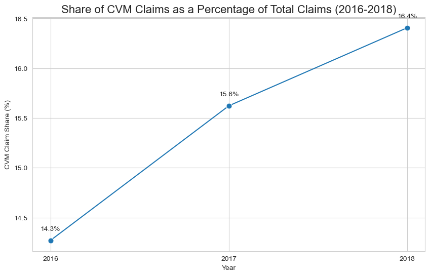

```python
import matplotlib.pyplot as plt
import seaborn as sns
import pandas as pd

# Set a nice style for the plot
sns.set_style("whitegrid")

# ====================================================================
# STEP 1: Data Preparation — Tagging and Filtering
# ====================================================================

# Ensure claim_year is a number (it's loaded as an object/string)
medicare_df['claim_year'] = pd.to_numeric(medicare_df['claim_year'], errors='coerce')

# Filter for the study period (2016-2018) *before* grouping for efficiency
# We also drop any rows where the year might be null
df_study_period = medicare_df[
    (medicare_df['claim_year'] >= 2016) & (medicare_df['claim_year'] <= 2018)
].copy()

# 💡 Define CVM claims: Using ICD-10 'I' codes (circulatory system)
# This is a robust way to find all cardiovascular-related claims.
df_study_period['is_cvm'] = df_study_period['diagnosis_code'].astype(str).str.startswith('I', na=False)

# ====================================================================
# STEP 2: Trend Calculation
# ====================================================================

# Count unique claim IDs by year and CVM type
cvm_trend = (
    df_study_period
    .groupby(['claim_year', 'is_cvm'])['claim_id']
    .nunique() # Count distinct claim IDs
    .unstack(fill_value=0)
    .rename(columns={True: 'CVM Claims', False: 'Non-CVM Claims'})
)

# Calculate totals and the percentage share
cvm_trend['Total Claims'] = cvm_trend['CVM Claims'] + cvm_trend['Non-CVM Claims']
cvm_trend['CVM Share (%)'] = (cvm_trend['CVM Claims'] / cvm_trend['Total Claims']) * 100

# Display the final data table
print("CVM Claim Trend Analysis (2016-2018)")
display(cvm_trend)

# ====================================================================
# STEP 3: Visualization
# ====================================================================

plt.figure(figsize=(10, 6))

# Plot the CVM Share percentage
ax = sns.lineplot(
    data=cvm_trend,
    x=cvm_trend.index,
    y='CVM Share (%)',
    marker='o',
    markersize=8
)

ax.set_title('Share of CVM Claims as a Percentage of Total Claims (2016-2018)', fontsize=16)
ax.set_ylabel('CVM Claim Share (%)')
ax.set_xlabel('Year')
ax.set_xticks([2016, 2017, 2018]) # Ensure clean x-axis ticks

# Add percentage labels to each point
for year, row in cvm_trend.iterrows():
    plt.text(
        year,
        row['CVM Share (%)'] + 0.1, # Offset label slightly
        f"{row['CVM Share (%)']:.1f}%",
        ha='center'
    )

plt.show()
```

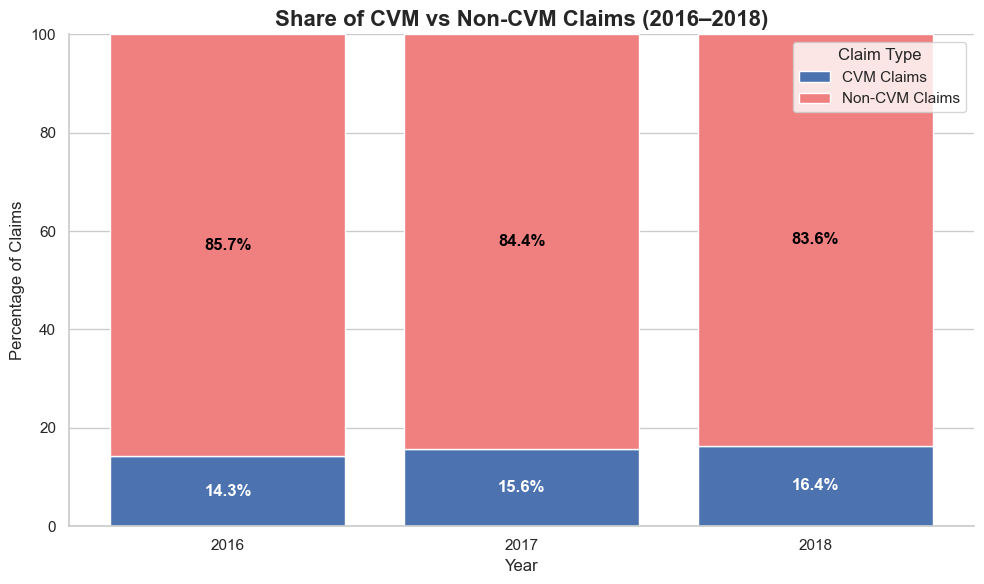

```python
import matplotlib.pyplot as plt
import seaborn as sns
import pandas as pd

# Theme and color setup
sns.set_theme(style="whitegrid")
colors = ['#4C72B0', '#F08080']  # CVM = blue, Non-CVM = salmon

# Prepare data
df_study_period['claim_year'] = pd.to_numeric(df_study_period['claim_year'], errors='coerce')
df_study_period = df_study_period[
    (df_study_period['claim_year'] >= 2016) & (df_study_period['claim_year'] <= 2018)
].copy()

df_study_period['is_cvm'] = df_study_period['diagnosis_code'].astype(str).str.startswith('I', na=False)

cvm_trend = (
    df_study_period
    .groupby(['claim_year', 'is_cvm'])['claim_id']
    .nunique()
    .unstack(fill_value=0)
    .rename(columns={True: 'CVM Claims', False: 'Non-CVM Claims'})
)

# Convert raw values to percentages for stacking
cvm_trend_pct = cvm_trend.div(cvm_trend.sum(axis=1), axis=0) * 100

# Plot
fig, ax = plt.subplots(figsize=(10, 6))
bottoms = [0] * len(cvm_trend_pct)

for idx, col in enumerate(['CVM Claims', 'Non-CVM Claims']):
    values = cvm_trend_pct[col].values
    ax.bar(cvm_trend_pct.index, values, bottom=bottoms, label=col, color=colors[idx])
    bottoms = [i + j for i, j in zip(bottoms, values)]

# Add annotations
for i, year in enumerate(cvm_trend_pct.index):
    cvm_val = cvm_trend_pct.loc[year, 'CVM Claims']
    ax.text(year, cvm_val / 2, f"{cvm_val:.1f}%", ha='center', va='center', color='white', fontweight='bold')
    ax.text(year, cvm_val + (cvm_trend_pct.loc[year, 'Non-CVM Claims'] / 2),
            f"{cvm_trend_pct.loc[year, 'Non-CVM Claims']:.1f}%",
            ha='center', va='center', color='black', fontweight='bold')

# Labels and styling
ax.set_title("Share of CVM vs Non-CVM Claims (2016–2018)", fontsize=16, fontweight='bold')
ax.set_ylabel("Percentage of Claims", fontsize=12)
ax.set_xlabel("Year", fontsize=12)
ax.set_ylim(0, 100)
ax.set_xticks([2016, 2017, 2018])
ax.legend(title="Claim Type", loc='upper right')
sns.despine()
plt.tight_layout()
plt.show()
```